# swirl

*そうです。それが、期待したものです。*

```
| Each column of shape_mat gives the minimum (row 1) and maximum (row 2) number of times its
| respective shape appears in different flags.

...
```

*shape_mat の各列は、異なる国旗の中に、それぞれの形が何回現れるか、（第一行に）その最小数と、（第二行に）最大数を表しています。*

```
| Use the class() function to confirm that shape_mat is a matrix.
```

*class() 関数を使って、shape_mat が行列であることを確認してください。*

```
> class(shape_mat)
[1] "matrix"

| All that hard work is paying off!
```

*努力は報われます。*

```
| As we've seen, sapply() always attempts to simplify the result given by lapply(). It has been
| successful in doing so for each of the examples we've looked at so far. Let's look at an example
| where sapply() can't figure out how to simplify the result and thus returns a list, no different
| from lapply().

...
```

*これまで見てきたように、sapply() 関数は、lapply() によって得られた結果を簡単にしようとします。これまでに見てきた例では、そのことに成功してきました。sapply() が結果を簡単にすることができなず、リストを返すことになる例を見てみましょう。この場合は、結果は、lapply() と同じになります。*

```
| When given a vector, the unique() function returns a vector with all duplicate elements removed.
| In other words, unique() returns a vector of only the 'unique' elements. To see how it works,
| try unique(c(3, 4, 5, 5, 5, 6, 6)).
```

*ベクトルに対して、unique() 関数は、重複したものを除いたベクトルを返します。他の言葉で言うと、unique() は、‘unique’（唯一の）成分だけからなるベクトルを返します。このことを、unique(c(3, 4, 5, 5, 5, 6, 6)) を使って見てみましょう。*

```
> unique(c(3, 4, 5, 5, 5, 6, 6))
[1] 3 4 5 6

| Excellent job!
```

*素晴らしい。*

```
| We want to know the unique values for each variable in the flags dataset. To accomplish this,
| use lapply() to apply the unique() function to each column in the flags dataset, storing the
| result in a variable called unique_vals.
```

*flags データセットにおいて、各変数について、unique values（相異なる値）を調べてみましょう。このため、lapply() を使って、unique() を flags データセットの各列に適用します。結果を、unique_vals に保存してください。*

```
> unique_vals <- lapply(flags, unique)

| Keep up the great work!
```

*その調子です。*

```
| Print the value of unique_vals to the console.
```

*unique_vals をコンソールに表示してください。*

```
> unique_vals
$name
  [1] Afghanistan              Albania                  Algeria
  [4] American-Samoa           Andorra                  Angola
  [7] Anguilla                 Antigua-Barbuda          Argentina
 [10] Argentine                Australia                Austria
 [13] Bahamas                  Bahrain                  Bangladesh
 [16] Barbados                 Belgium                  Belize
 [19] Benin                    Bermuda                  Bhutan
 [22] Bolivia                  Botswana                 Brazil
 [25] British-Virgin-Isles     Brunei                   Bulgaria
 [28] Burkina                  Burma                    Burundi
 [31] Cameroon                 Canada                   Cape-Verde-Islands
 [34] Cayman-Islands           Central-African-Republic Chad
 [37] Chile                    China                    Colombia
 [40] Comorro-Islands          Congo                    Cook-Islands
 [43] Costa-Rica               Cuba                     Cyprus
 [46] Czechoslovakia           Denmark                  Djibouti
 [49] Dominica                 Dominican-Republic       Ecuador
 [52] Egypt                    El-Salvador              Equatorial-Guinea
 [55] Ethiopia                 Faeroes                  Falklands-Malvinas
 [58] Fiji                     Finland                  France
 [61] French-Guiana            French-Polynesia         Gabon
 [64] Gambia                   Germany-DDR              Germany-FRG
 [67] Ghana                    Gibraltar                Greece
 [70] Greenland                Grenada                  Guam
 [73] Guatemala                Guinea                   Guinea-Bissau
 [76] Guyana                   Haiti                    Honduras
 [79] Hong-Kong                Hungary                  Iceland
 [82] India                    Indonesia                Iran
 [85] Iraq                     Ireland                  Israel
 [88] Italy                    Ivory-Coast              Jamaica
 [91] Japan                    Jordan                   Kampuchea
 [94] Kenya                    Kiribati                 Kuwait
 [97] Laos                     Lebanon                  Lesotho
[100] Liberia                  Libya                    Liechtenstein
[103] Luxembourg               Malagasy                 Malawi
[106] Malaysia                 Maldive-Islands          Mali
[109] Malta                    Marianas                 Mauritania
[112] Mauritius                Mexico                   Micronesia
[115] Monaco                   Mongolia                 Montserrat
[118] Morocco                  Mozambique               Nauru
[121] Nepal                    Netherlands              Netherlands-Antilles
[124] New-Zealand              Nicaragua                Niger
[127] Nigeria                  Niue                     North-Korea
[130] North-Yemen              Norway                   Oman
[133] Pakistan                 Panama                   Papua-New-Guinea
[136] Parguay                  Peru                     Philippines
[139] Poland                   Portugal                 Puerto-Rico
[142] Qatar                    Romania                  Rwanda
[145] San-Marino               Sao-Tome                 Saudi-Arabia
[148] Senegal                  Seychelles               Sierra-Leone
[151] Singapore                Soloman-Islands          Somalia
[154] South-Africa             South-Korea              South-Yemen
[157] Spain                    Sri-Lanka                St-Helena
[160] St-Kitts-Nevis           St-Lucia                 St-Vincent
[163] Sudan                    Surinam                  Swaziland
[166] Sweden                   Switzerland              Syria
[169] Taiwan                   Tanzania                 Thailand
[172] Togo                     Tonga                    Trinidad-Tobago
[175] Tunisia                  Turkey                   Turks-Cocos-Islands
[178] Tuvalu                   UAE                      Uganda
[181] UK                       Uruguay                  US-Virgin-Isles
[184] USA                      USSR                     Vanuatu
[187] Vatican-City             Venezuela                Vietnam
[190] Western-Samoa            Yugoslavia               Zaire
[193] Zambia                   Zimbabwe
194 Levels: Afghanistan Albania Algeria American-Samoa Andorra Angola Anguilla ... Zimbabwe

$landmass
[1] 5 3 4 6 1 2

$zone
[1] 1 3 2 4

$area
  [1]   648    29  2388     0  1247  2777  7690    84    19     1   143    31    23   113    47
 [16]  1099   600  8512     6   111   274   678    28   474  9976     4   623  1284   757  9561
 [31]  1139     2   342    51   115     9   128    43    22    49   284  1001    21  1222    12
 [46]    18   337   547    91   268    10   108   249   239   132  2176   109   246    36   215
 [61]   112    93   103  3268  1904  1648   435    70   301   323    11   372    98   181   583
 [76]   236    30  1760     3   587   118   333  1240  1031  1973  1566   447   783   140    41
 [91]  1267   925   121   195   324   212   804    76   463   407  1285   300   313    92   237
[106]    26  2150   196    72   637  1221    99   288   505    66  2506    63    17   450   185
[121]   945   514    57     5   164   781   245   178  9363 22402    15   912   256   905   753
[136]   391

$population
 [1]   16    3   20    0    7   28   15    8   90   10    1    6  119    9   35    4   24    2   11
[20] 1008    5   47   31   54   17   61   14  684  157   39   57  118   13   77   12   56   18   84
[39]   48   36   22   29   38   49   45  231  274   60

$language
 [1] 10  6  8  1  2  4  3  5  7  9

$religion
[1] 2 6 1 0 5 3 4 7

$bars
[1] 0 2 3 1 5

$stripes
 [1]  3  0  2  1  5  9 11 14  4  6 13  7

$colours
[1] 5 3 2 8 6 4 7 1

$red
[1] 1 0

$green
[1] 1 0

$blue
[1] 0 1

$gold
[1] 1 0

$white
[1] 1 0

$black
[1] 1 0

$orange
[1] 0 1

$mainhue
[1] green  red    blue   gold   white  orange black  brown
Levels: black blue brown gold green orange red white

$circles
[1] 0 1 4 2

$crosses
[1] 0 1 2

$saltires
[1] 0 1

$quarters
[1] 0 1 4

$sunstars
 [1]  1  0  6 22 14  3  4  5 15 10  7  2  9 50

$crescent
[1] 0 1

$triangle
[1] 0 1

$icon
[1] 1 0

$animate
[1] 0 1

$text
[1] 0 1

$topleft
[1] black  red    green  blue   white  orange gold
Levels: black blue gold green orange red white

$botright
[1] green  red    white  black  blue   gold   orange brown
Levels: black blue brown gold green orange red white


| Great job!
```

*やりましたね。*

```
| Since unique_vals is a list, you can use what you've learned to determine the length of each
| element of unique_vals (i.e. the number of unique values for each variable). Simplify the
| result, if possible. Hint: Apply the length() function to each element of unique_vals.
```

*unique_vals はリストですから、unique_vals のそれぞれの成分の長さを調べることができますね。（各変数の相異なる値の数です。）可能なら、簡単にしてみましょう。ヒント：unique_vals の各正文に、length() を適用してください。*

```
> sapply(unique_vals, length)
      name   landmass       zone       area population   language   religion       bars    stripes
       194          6          4        136         48         10          8          5         12
   colours        red      green       blue       gold      white      black     orange    mainhue
         8          2          2          2          2          2          2          2          8
   circles    crosses   saltires   quarters   sunstars   crescent   triangle       icon    animate
         4          3          2          3         14          2          2          2          2
      text    topleft   botright
         2          7          8

| You nailed it! Good job!
```

*見事です。*

```
| The fact that the elements of the unique_vals list are all vectors of *different* length poses a
| problem for sapply(), since there's no obvious way of simplifying the result.

...
```

*unique_vals リストの成分は、長さが異なるベクトルであることがわかりました。だから、sapply() によって、結果を明らかな方法では、簡単にすることができなかったのです。*

```
| Use sapply() to apply the unique() function to each column of the flags dataset to see that you
| get the same unsimplified list that you got from lapply().
```

*flags データセットに、sapply() 関数をもちい、unique() 関数を各列に適用して、lapply() で得たのと同じ、簡単になっていないリストを返すことを確認してみてください。*

```
> sapply(flags, unique)
$name
  [1] Afghanistan              Albania                  Algeria
  [4] American-Samoa           Andorra                  Angola
  [7] Anguilla                 Antigua-Barbuda          Argentina
 [10] Argentine                Australia                Austria
 [13] Bahamas                  Bahrain                  Bangladesh
 [16] Barbados                 Belgium                  Belize
 [19] Benin                    Bermuda                  Bhutan
 [22] Bolivia                  Botswana                 Brazil
 [25] British-Virgin-Isles     Brunei                   Bulgaria
 [28] Burkina                  Burma                    Burundi
 [31] Cameroon                 Canada                   Cape-Verde-Islands
 [34] Cayman-Islands           Central-African-Republic Chad
 [37] Chile                    China                    Colombia
 [40] Comorro-Islands          Congo                    Cook-Islands
 [43] Costa-Rica               Cuba                     Cyprus
 [46] Czechoslovakia           Denmark                  Djibouti
 [49] Dominica                 Dominican-Republic       Ecuador
 [52] Egypt                    El-Salvador              Equatorial-Guinea
 [55] Ethiopia                 Faeroes                  Falklands-Malvinas
 [58] Fiji                     Finland                  France
 [61] French-Guiana            French-Polynesia         Gabon
 [64] Gambia                   Germany-DDR              Germany-FRG
 [67] Ghana                    Gibraltar                Greece
 [70] Greenland                Grenada                  Guam
 [73] Guatemala                Guinea                   Guinea-Bissau
 [76] Guyana                   Haiti                    Honduras
 [79] Hong-Kong                Hungary                  Iceland
 [82] India                    Indonesia                Iran
 [85] Iraq                     Ireland                  Israel
 [88] Italy                    Ivory-Coast              Jamaica
 [91] Japan                    Jordan                   Kampuchea
 [94] Kenya                    Kiribati                 Kuwait
 [97] Laos                     Lebanon                  Lesotho
[100] Liberia                  Libya                    Liechtenstein
[103] Luxembourg               Malagasy                 Malawi
[106] Malaysia                 Maldive-Islands          Mali
[109] Malta                    Marianas                 Mauritania
[112] Mauritius                Mexico                   Micronesia
[115] Monaco                   Mongolia                 Montserrat
[118] Morocco                  Mozambique               Nauru
[121] Nepal                    Netherlands              Netherlands-Antilles
[124] New-Zealand              Nicaragua                Niger
[127] Nigeria                  Niue                     North-Korea
[130] North-Yemen              Norway                   Oman
[133] Pakistan                 Panama                   Papua-New-Guinea
[136] Parguay                  Peru                     Philippines
[139] Poland                   Portugal                 Puerto-Rico
[142] Qatar                    Romania                  Rwanda
[145] San-Marino               Sao-Tome                 Saudi-Arabia
[148] Senegal                  Seychelles               Sierra-Leone
[151] Singapore                Soloman-Islands          Somalia
[154] South-Africa             South-Korea              South-Yemen
[157] Spain                    Sri-Lanka                St-Helena
[160] St-Kitts-Nevis           St-Lucia                 St-Vincent
[163] Sudan                    Surinam                  Swaziland
[166] Sweden                   Switzerland              Syria
[169] Taiwan                   Tanzania                 Thailand
[172] Togo                     Tonga                    Trinidad-Tobago
[175] Tunisia                  Turkey                   Turks-Cocos-Islands
[178] Tuvalu                   UAE                      Uganda
[181] UK                       Uruguay                  US-Virgin-Isles
[184] USA                      USSR                     Vanuatu
[187] Vatican-City             Venezuela                Vietnam
[190] Western-Samoa            Yugoslavia               Zaire
[193] Zambia                   Zimbabwe
194 Levels: Afghanistan Albania Algeria American-Samoa Andorra Angola Anguilla ... Zimbabwe

$landmass
[1] 5 3 4 6 1 2

$zone
[1] 1 3 2 4

$area
  [1]   648    29  2388     0  1247  2777  7690    84    19     1   143    31    23   113    47
 [16]  1099   600  8512     6   111   274   678    28   474  9976     4   623  1284   757  9561
 [31]  1139     2   342    51   115     9   128    43    22    49   284  1001    21  1222    12
 [46]    18   337   547    91   268    10   108   249   239   132  2176   109   246    36   215
 [61]   112    93   103  3268  1904  1648   435    70   301   323    11   372    98   181   583
 [76]   236    30  1760     3   587   118   333  1240  1031  1973  1566   447   783   140    41
 [91]  1267   925   121   195   324   212   804    76   463   407  1285   300   313    92   237
[106]    26  2150   196    72   637  1221    99   288   505    66  2506    63    17   450   185
[121]   945   514    57     5   164   781   245   178  9363 22402    15   912   256   905   753
[136]   391

$population
 [1]   16    3   20    0    7   28   15    8   90   10    1    6  119    9   35    4   24    2   11
[20] 1008    5   47   31   54   17   61   14  684  157   39   57  118   13   77   12   56   18   84
[39]   48   36   22   29   38   49   45  231  274   60

$language
 [1] 10  6  8  1  2  4  3  5  7  9

$religion
[1] 2 6 1 0 5 3 4 7

$bars
[1] 0 2 3 1 5

$stripes
 [1]  3  0  2  1  5  9 11 14  4  6 13  7

$colours
[1] 5 3 2 8 6 4 7 1

$red
[1] 1 0

$green
[1] 1 0

$blue
[1] 0 1

$gold
[1] 1 0

$white
[1] 1 0

$black
[1] 1 0

$orange
[1] 0 1

$mainhue
[1] green  red    blue   gold   white  orange black  brown
Levels: black blue brown gold green orange red white

$circles
[1] 0 1 4 2

$crosses
[1] 0 1 2

$saltires
[1] 0 1

$quarters
[1] 0 1 4

$sunstars
 [1]  1  0  6 22 14  3  4  5 15 10  7  2  9 50

$crescent
[1] 0 1

$triangle
[1] 0 1

$icon
[1] 1 0

$animate
[1] 0 1

$text
[1] 0 1

$topleft
[1] black  red    green  blue   white  orange gold
Levels: black blue gold green orange red white

$botright
[1] green  red    white  black  blue   gold   orange brown
Levels: black blue brown gold green orange red white


| Excellent work!
```

*素晴らしい。*

```
| Occasionally, you may need to apply a function that is not yet defined, thus requiring you to
| write your own. Writing functions in R is beyond the scope of this lesson, but let's look at a
| quick example of how you might do so in the context of loop functions.

...
```

*しばしば、定義されていない関数を、そのばでプログラムして、適用する必要があることが生じます。R の関数をプログラムすることは、このコースの範囲を超えていますが、loop 関数という枠組みの中で、簡単に見てみましょう。*

```
| Pretend you are interested in only the second item from each element of the unique_vals list
| that you just created. Since each element of the unique_vals list is a vector and we're not
| aware of any built-in function in R that returns the second element of a vector, we will
| construct our own function.

...
```

*unique_vals のそれぞれの二番目の項目だけが、必要だということを想像してみましょう。unique_vals リストの要素は、ベクトルで、R の関数で、その二番目の成分を取り出すものは、知らないとしましょう。そこで、自分でそのような関数をプログラムします。*

```
| lapply(unique_vals, function(elem) elem[2]) will return a list containing the second item from
| each element of the unique_vals list. Note that our function takes one argument, elem, which is
| just a 'dummy variable' that takes on the value of each element of unique_vals, in turn.
```

*lapply(unique_vals, function(elem) elem[2]) が unique_vals の各成分の二番目の値を返してくれいます。ここで書いた関数は、引数は、elem という名前の一つで、それは、‘dummy variable’（仮の変数）で、unique_vals の各成分を値とします。*

```
> lapply(unique_vals, function(elem) elem[2])
$name
[1] Albania
194 Levels: Afghanistan Albania Algeria American-Samoa Andorra Angola Anguilla ... Zimbabwe

$landmass
[1] 3

$zone
[1] 3

$area
[1] 29

$population
[1] 3

$language
[1] 6

$religion
[1] 6

$bars
[1] 2

$stripes
[1] 0

$colours
[1] 3

$red
[1] 0

$green
[1] 0

$blue
[1] 1

$gold
[1] 0

$white
[1] 0

$black
[1] 0

$orange
[1] 1

$mainhue
[1] red
Levels: black blue brown gold green orange red white

$circles
[1] 1

$crosses
[1] 1

$saltires
[1] 1

$quarters
[1] 1

$sunstars
[1] 0

$crescent
[1] 1

$triangle
[1] 1

$icon
[1] 0

$animate
[1] 1

$text
[1] 1

$topleft
[1] red
Levels: black blue gold green orange red white

$botright
[1] red
Levels: black blue brown gold green orange red white


| All that hard work is paying off!
```

*努力は報われます。*

```
| The only difference between previous examples and this one is that we are defining and using our
| own function right in the call to lapply(). Our function has no name and disappears as soon as
| lapply() is done using it. So-called 'anonymous functions' can be very useful when one of R's
| built-in functions isn't an option.

...
```

*前の例との違いは、この例では、自分の関数を定義して、それを lapply() に適用したことです。この関数は、名前もなく、lapply() が使ったあとには、消えてしまいます。このように、R に付属していない関数を使うときには、‘anonymous functions’（匿名関数）は有効です。*

```
  |=======================================================================================  |  98%
| In this lesson, you learned how to use the powerful lapply() and sapply() functions to apply an
| operation over the elements of a list. In the next lesson, we'll take a look at some close
| relatives of lapply() and sapply().

...
```

*この課では、強力な lapply() と sapply() という二つの関数を、リストのそれぞれに適用する方法について、学びました。次の課では、lapply() と sapply() の親戚について、さらに学びます。*

```
  |=========================================================================================| 100%
| Would you like to receive credit for completing this course on Coursera.org?

1: No
2: Yes

Selection: 1
```

*Coursera.org の終了認定が欲しいですか。*

*1 を選んでください。何度か説明しましたから、省略します。*

```
| All that practice is paying off!

| You've reached the end of this lesson! Returning to the main menu...

| Please choose a course, or type 0 to exit swirl.

1: R Programming
2: Take me to the swirl course repository!

Selection: 0
```

*練習のおかげですね。*

*課の最後までたどり着きました。メニューに戻るには、*

*コースを選択してください。swirl を終了するときは、0 を入力してください。*

*1: R によるプログラム*  
*2: ｀swirl` コースのリストへ.*

*選択：0 （SL が入力）*

```
| Leaving swirl now. Type swirl() to resume.
```

*swirl を終了します。再開するときは、swirl() と入力してください。*

```
>
```

#### FLAGs Dataset

> 2.10 で利用した、FLAGs データセットの基本情報は viewinfo() 関数で見ることができます。出力は次のようになります。これを見ると、このデータセットはどのようなもので、それぞれの変数（列）には、どのような情報が記録されているかの概要がわかります。多くのデータセットには、このような情報がありますから、利用の前に、確認することが大切です。

**flag.names.txt**

```
1. Title: Flag database

2. Source Information
   -- Creators: Collected primarily from the "Collins Gem Guide to Flags":
      Collins Publishers (1986).
   -- Donor: Richard S. Forsyth
             8 Grosvenor Avenue
             Mapperley Park
             Nottingham NG3 5DX
             0602-621676
   -- Date: 5/15/1990

3. Past Usage:
   -- None known other than what is shown in Forsyth's PC/BEAGLE User's Guide.

4. Relevant Information:
   -- This data file contains details of various nations and their flags.
      In this file the fields are separated by spaces (not commas).  With
      this data you can try things like predicting the religion of a country
      from its size and the colours in its flag.
   -- 10 attributes are numeric-valued.  The remainder are either Boolean-
      or nominal-valued.

5. Number of Instances: 194

6. Number of attributes: 30 (overall)

7. Attribute Information:
   1. name  Name of the country concerned
   2. landmass  1=N.America, 2=S.America, 3=Europe, 4=Africa, 4=Asia, 6=Oceania
   3. zone  Geographic quadrant, based on Greenwich and the Equator
                1=NE, 2=SE, 3=SW, 4=NW
   4. area  in thousands of square km
   5. population    in round millions
   6. language 1=English, 2=Spanish, 3=French, 4=German, 5=Slavic, 6=Other
               Indo-European, 7=Chinese, 8=Arabic,
               9=Japanese/Turkish/Finnish/Magyar, 10=Others
   7. religion 0=Catholic, 1=Other Christian, 2=Muslim, 3=Buddhist, 4=Hindu,
               5=Ethnic, 6=Marxist, 7=Others
   8. bars     Number of vertical bars in the flag
   9. stripes  Number of horizontal stripes in the flag
  10. colours  Number of different colours in the flag
  11. red      0 if red absent, 1 if red present in the flag
  12. green    same for green
  13. blue     same for blue
  14. gold     same for gold (also yellow)
  15. white    same for white
  16. black    same for black
  17. orange   same for orange (also brown)
  18. mainhue  predominant colour in the flag (tie-breaks decided by taking
               the topmost hue, if that fails then the most central hue,
               and if that fails the leftmost hue)
  19. circles  Number of circles in the flag
  20. crosses  Number of (upright) crosses
  21. saltires Number of diagonal crosses
  22. quarters Number of quartered sections
  23. sunstars Number of sun or star symbols
  24. crescent 1 if a crescent moon symbol present, else 0
  25. triangle 1 if any triangles present, 0 otherwise
  26. icon     1 if an inanimate image present (e.g., a boat), otherwise 0
  27. animate  1 if an animate image (e.g., an eagle, a tree, a human hand)
               present, 0 otherwise
  28. text     1 if any letters or writing on the flag (e.g., a motto or
               slogan), 0 otherwise
  29. topleft  colour in the top-left corner (moving right to decide
               tie-breaks)
  30. botright Colour in the bottom-left corner (moving left to decide
               tie-breaks)

8. Missing values: None
```

### 2.11. vapply and tapply

> 前の課で学んだ、lapply と sapply の親戚である、vapply tapply について学びます。  
> 和訳や解説は、課を選択するところから始めます。よくわからない方は、1.2 または、1.1 の最初の部分を復習してください。

```
| Please choose a course, or type 0 to exit swirl.

1: R Programming
2: Take me to the swirl course repository!

Selection: 1

| Please choose a lesson, or type 0 to return to course menu.

 1: Basic Building Blocks      2: Workspace and Files        3: Sequences of Numbers
 4: Vectors                    5: Missing Values             6: Subsetting Vectors
 7: Matrices and Data Frames   8: Logic                      9: Functions
10: lapply and sapply         11: vapply and tapply         12: Looking at Data
13: Simulation                14: Dates and Times           15: Base Graphics


Selection: 11
```

11: vapply and tapply（第11課 vapply and tapply）を選択しました。

```
| In the last lesson, you learned about the two most fundamental members of R's *apply family of
| functions: lapply() and sapply(). Both take a list as input, apply a function to each element of
| the list, then combine and return the result. lapply() always returns a list, whereas sapply()
| attempts to simplify the result.

...
```

_前の課では、R の *apply 系列の二つの基本的な関数である、lapply() と sapply() について学びました。どちらも、list を入力し、リストのそれぞれの要素に関数を適用します。そして、結果を連結させて出力します。lapply() は常に、リストを返しますが、sapply() は、結果を簡単にすることを試みます。_

```
| In this lesson, you'll learn how to use vapply() and tapply(), each of which serves a very
| specific purpose within the Split-Apply-Combine methodology. For consistency, we'll use the same
| dataset we used in the 'lapply and sapply' lesson.

...
```

*この課では、vapply() と tapply() について学びます。どちらも、Split-Apply-Combine（分解して、適用して、連結させる）手法を実行します。続きであることを意識して、lapply() と sapply() を学んだときと同じデータセットを使います。*

```
| The Flags dataset from the UCI Machine Learning Repository contains details of various nations
| and their flags. More information may be found here:
| http://archive.ics.uci.edu/ml/datasets/Flags

...
```

*Flags データセットは、UCI Machine Learning Repository（カリフォルニア大学アーバイン校の機械学習のためのデータ庫）からのもので、http://archive.ics.uci.edu/ml/datasets/Flags に詳しい情報があります。*

```
| I've stored the data in a variable called flags. If it's been a while since you completed the
| 'lapply and sapply' lesson, you may want to reacquaint yourself with the data by using functions
| like dim(), head(), str(), and summary() when you return to the prompt (>). You can also type
| viewinfo() at the prompt to bring up some documentation for the dataset. Let's get started!

...
```

*flag という名前の変数にデータを割り当ててあります。‘lapply’ と ‘sapply’ を学んでしばらくたっているのであれば、（いったん、swirl から抜けて）Prompt (>) で、dim(), head(), str(), や summary() を試してください。また、viewinfo() として、このデータセットに関する文書をみてみるのも良いでしょう。はじめましょう。*

viewinfo() の情報は、flag.names.txt とというファイルにあり、その内容は、この課のノートの直前、前の課の最後に掲載してあります。また、この課の最後に、dim(), head(), str(), や summary() の結果の、Console Log を載せましたので、参考にしてください。

```
| As you saw in the last lesson, the unique() function returns a vector of the unique values
| contained in the object passed to it. Therefore, sapply(flags, unique) returns a list containing
| one vector of unique values for each column of the flags dataset. Try it again now.
```

*前の課で見たように、unique() 関数は、そのオブジェクトに含まれる相異なる値をベクトルにして返します。そこで、sapply(flags, unique) は、flag データセットの各列の相異なる値をベクトルにして、リストにまとめて返します。試してください。*

```
> sapply(flags, unique)
$name
  [1] Afghanistan              Albania                  Algeria
  [4] American-Samoa           Andorra                  Angola
  [7] Anguilla                 Antigua-Barbuda          Argentina
 [10] Argentine                Australia                Austria
 [13] Bahamas                  Bahrain                  Bangladesh
 [16] Barbados                 Belgium                  Belize
 [19] Benin                    Bermuda                  Bhutan
 [22] Bolivia                  Botswana                 Brazil
 [25] British-Virgin-Isles     Brunei                   Bulgaria
 [28] Burkina                  Burma                    Burundi
 [31] Cameroon                 Canada                   Cape-Verde-Islands
 [34] Cayman-Islands           Central-African-Republic Chad
 [37] Chile                    China                    Colombia
 [40] Comorro-Islands          Congo                    Cook-Islands
 [43] Costa-Rica               Cuba                     Cyprus
 [46] Czechoslovakia           Denmark                  Djibouti
 [49] Dominica                 Dominican-Republic       Ecuador
 [52] Egypt                    El-Salvador              Equatorial-Guinea
 [55] Ethiopia                 Faeroes                  Falklands-Malvinas
 [58] Fiji                     Finland                  France
 [61] French-Guiana            French-Polynesia         Gabon
 [64] Gambia                   Germany-DDR              Germany-FRG
 [67] Ghana                    Gibraltar                Greece
 [70] Greenland                Grenada                  Guam
 [73] Guatemala                Guinea                   Guinea-Bissau
 [76] Guyana                   Haiti                    Honduras
 [79] Hong-Kong                Hungary                  Iceland
 [82] India                    Indonesia                Iran
 [85] Iraq                     Ireland                  Israel
 [88] Italy                    Ivory-Coast              Jamaica
 [91] Japan                    Jordan                   Kampuchea
 [94] Kenya                    Kiribati                 Kuwait
 [97] Laos                     Lebanon                  Lesotho
[100] Liberia                  Libya                    Liechtenstein
[103] Luxembourg               Malagasy                 Malawi
[106] Malaysia                 Maldive-Islands          Mali
[109] Malta                    Marianas                 Mauritania
[112] Mauritius                Mexico                   Micronesia
[115] Monaco                   Mongolia                 Montserrat
[118] Morocco                  Mozambique               Nauru
[121] Nepal                    Netherlands              Netherlands-Antilles
[124] New-Zealand              Nicaragua                Niger
[127] Nigeria                  Niue                     North-Korea
[130] North-Yemen              Norway                   Oman
[133] Pakistan                 Panama                   Papua-New-Guinea
[136] Parguay                  Peru                     Philippines
[139] Poland                   Portugal                 Puerto-Rico
[142] Qatar                    Romania                  Rwanda
[145] San-Marino               Sao-Tome                 Saudi-Arabia
[148] Senegal                  Seychelles               Sierra-Leone
[151] Singapore                Soloman-Islands          Somalia
[154] South-Africa             South-Korea              South-Yemen
[157] Spain                    Sri-Lanka                St-Helena
[160] St-Kitts-Nevis           St-Lucia                 St-Vincent
[163] Sudan                    Surinam                  Swaziland
[166] Sweden                   Switzerland              Syria
[169] Taiwan                   Tanzania                 Thailand
[172] Togo                     Tonga                    Trinidad-Tobago
[175] Tunisia                  Turkey                   Turks-Cocos-Islands
[178] Tuvalu                   UAE                      Uganda
[181] UK                       Uruguay                  US-Virgin-Isles
[184] USA                      USSR                     Vanuatu
[187] Vatican-City             Venezuela                Vietnam
[190] Western-Samoa            Yugoslavia               Zaire
[193] Zambia                   Zimbabwe
194 Levels: Afghanistan Albania Algeria American-Samoa Andorra Angola Anguilla ... Zimbabwe

$landmass
[1] 5 3 4 6 1 2

$zone
[1] 1 3 2 4

$area
  [1]   648    29  2388     0  1247  2777  7690    84    19     1   143    31    23   113    47
 [16]  1099   600  8512     6   111   274   678    28   474  9976     4   623  1284   757  9561
 [31]  1139     2   342    51   115     9   128    43    22    49   284  1001    21  1222    12
 [46]    18   337   547    91   268    10   108   249   239   132  2176   109   246    36   215
 [61]   112    93   103  3268  1904  1648   435    70   301   323    11   372    98   181   583
 [76]   236    30  1760     3   587   118   333  1240  1031  1973  1566   447   783   140    41
 [91]  1267   925   121   195   324   212   804    76   463   407  1285   300   313    92   237
[106]    26  2150   196    72   637  1221    99   288   505    66  2506    63    17   450   185
[121]   945   514    57     5   164   781   245   178  9363 22402    15   912   256   905   753
[136]   391

$population
 [1]   16    3   20    0    7   28   15    8   90   10    1    6  119    9   35    4   24    2   11
[20] 1008    5   47   31   54   17   61   14  684  157   39   57  118   13   77   12   56   18   84
[39]   48   36   22   29   38   49   45  231  274   60

$language
 [1] 10  6  8  1  2  4  3  5  7  9

$religion
[1] 2 6 1 0 5 3 4 7

$bars
[1] 0 2 3 1 5

$stripes
 [1]  3  0  2  1  5  9 11 14  4  6 13  7

$colours
[1] 5 3 2 8 6 4 7 1

$red
[1] 1 0

$green
[1] 1 0

$blue
[1] 0 1

$gold
[1] 1 0

$white
[1] 1 0

$black
[1] 1 0

$orange
[1] 0 1

$mainhue
[1] green  red    blue   gold   white  orange black  brown
Levels: black blue brown gold green orange red white

$circles
[1] 0 1 4 2

$crosses
[1] 0 1 2

$saltires
[1] 0 1

$quarters
[1] 0 1 4

$sunstars
 [1]  1  0  6 22 14  3  4  5 15 10  7  2  9 50

$crescent
[1] 0 1

$triangle
[1] 0 1

$icon
[1] 1 0

$animate
[1] 0 1

$text
[1] 0 1

$topleft
[1] black  red    green  blue   white  orange gold
Levels: black blue gold green orange red white

$botright
[1] green  red    white  black  blue   gold   orange brown
Levels: black blue brown gold green orange red white


| Keep working like that and you'll get there!
```

*その調子で良いですよ。*

```
| What if you had forgotten how unique() works and mistakenly thought it returns the *number* of
| unique values contained in the object passed to it? Then you might have incorrectly expected
| sapply(flags, unique) to return a numeric vector, since each element of the list returned would
| contain a single number and sapply() could then simplify the result to a vector.

...
```

*たとえば、unique() がどのように作用するか忘れていて、渡したオブジェクトに含まれる相異なるものの**数**を返すと考えたとしましょう。すると、各値は、一つの数値ですから、sapply(flags, unique) は、簡単にして、ベクトルを返すと考えることになります。*

```
| When working interactively (at the prompt), this is not much of a problem, since you see the
| result immediately and will quickly recognize your mistake. However, when working
| non-interactively (e.g. writing your own functions), a misunderstanding may go undetected and
| cause incorrect results later on. Therefore, you may wish to be more careful and that's where
| vapply() is useful.

...
```

*Prompt に対話型で関数を入力し、作業を進めるときは、すぐに答えを見て、間違いに気づくので、あまり問題になりません。しかし、対話型ではなく、プログラムを書いて、作業を進めるときには、間違いに気づかずに過ぎてしまうかもしれません。従って、もっと、注意をする必要があります。このようなときに、vapply() は有効です。*

```
| Whereas sapply() tries to 'guess' the correct format of the result, vapply() allows you to
| specify it explicitly. If the result doesn't match the format you specify, vapply() will throw
| an error, causing the operation to stop. This can prevent significant problems in your code that
| might be caused by getting unexpected return values from sapply().

...
```

*sapply() では、結果の形式を推測して実行しますが、vapply() は明示的に、実行します。形式が適合しなければ、vapply() はエラーメッセージを出し、作業は停止します。これによって、sapply() が予想にない値を返し、重大な問題を生じることを避けることができます。*

```
| Try vapply(flags, unique, numeric(1)), which says that you expect each element of the result to
| be a numeric vector of length 1. Since this is NOT actually the case, YOU WILL GET AN ERROR.
| Once you get the error, type ok() to continue to the next question.
```

*vapply(flags, unique, numeric(1)) と入力しましょう。これは、結果が、長さが１の数値ベクトルを返す事を期待していることを意味します。これは、実際には、正しくないので、エラーをひきおこします。エラーになったら、ok() と入力すると、次の問題を続けることができます。*

```
> vapply(flags, unique, numeric(1))
Error in vapply(flags, unique, numeric(1)) : values must be length 1,
 but FUN(X[[1]]) result is length 194
[日本語の場合のエラーメッセージ] vapply(flags, unique, numeric(1)) でエラー:
   値の長さは 1 でなければなりません、
 しかし、FUN(X[[1]]) の結果の長さが 194 です

> ok()

| You are doing so well!
```

*とてもうまくいっていますよ。*

```
| Recall from the previous lesson that sapply(flags, class) will return a character vector
| containing the class of each column in the dataset. Try that again now to see the result.
```

*前の課で学んだように、sapply(flags, class) は、データセットの各列の種類（class）を表す文字列ベクトルを返すのでした。もう一度試してください。*

```
> sapply(flags, class)
      name   landmass       zone       area population   language   religion       bars    stripes
  "factor"  "integer"  "integer"  "integer"  "integer"  "integer"  "integer"  "integer"  "integer"
   colours        red      green       blue       gold      white      black     orange    mainhue
 "integer"  "integer"  "integer"  "integer"  "integer"  "integer"  "integer"  "integer"   "factor"
   circles    crosses   saltires   quarters   sunstars   crescent   triangle       icon    animate
 "integer"  "integer"  "integer"  "integer"  "integer"  "integer"  "integer"  "integer"  "integer"
      text    topleft   botright
 "integer"   "factor"   "factor"

| All that hard work is paying off!
```

*努力は報われます。*

```
| If we wish to be explicit about the format of the result we expect, we can use vapply(flags,
| class, character(1)). The 'character(1)' argument tells R that we expect the class function to
| return a character vector of length 1 when applied to EACH column of the flags dataset. Try it
| now.
```

*出力としてなにを期待しているかを明示的にするには、vapply(flags, class, character(1)) とします。引数の ‘character(1)’ は、R に、flag データセットの各列に、class 関数を適用した結果として、長さ 1 の文字列ベクトルを返すことを期待していると伝えています。試してください。*

```
> vapply(flags, class, character(1))
      name   landmass       zone       area population   language   religion       bars    stripes
  "factor"  "integer"  "integer"  "integer"  "integer"  "integer"  "integer"  "integer"  "integer"
   colours        red      green       blue       gold      white      black     orange    mainhue
 "integer"  "integer"  "integer"  "integer"  "integer"  "integer"  "integer"  "integer"   "factor"
   circles    crosses   saltires   quarters   sunstars   crescent   triangle       icon    animate
 "integer"  "integer"  "integer"  "integer"  "integer"  "integer"  "integer"  "integer"  "integer"
      text    topleft   botright
 "integer"   "factor"   "factor"

| You nailed it! Good job!
```

*見事です。*

```
| Note that since our expectation was correct (i.e. character(1)), the vapply() result is
| identical to the sapply() result -- a character vector of column classes.

...
```

*確かに、予測は正しく（character(1)）、vapply() は、sapply() と全く同じ結果、すなわち、各列の種類（class）を返しました。*

```
| You might think of vapply() as being 'safer' than sapply(), since it requires you to specify the
| format of the output in advance, instead of just allowing R to 'guess' what you wanted. In
| addition, vapply() may perform faster than sapply() for large datasets. However, when doing data
| analysis interactively (at the prompt), sapply() saves you some typing and will often be good
| enough.

...
```

*vapply() は、sapply() のように、R に、結果を推測させるのではなく、具体的な形式を前もって指定するので、より安全だと思うでしょう。さらに、vapply() は sapply() と比較して、特に大きなデータセットに対しては、実行速度が速いのです。しかし、Prompt に対して、対話型で、作業を進めるときは、sapply() は、入力を減らしますし、多くの場合、それで十分でもあります。*

```
| As a data analyst, you'll often wish to split your data up into groups based on the value of
| some variable, then apply a function to the members of each group. The next function we'll look
| at, tapply(), does exactly that.

...
```

*データ分析をしようとすると、まず、データを、ある変数の値によって、いくつかに分割し、分割したグループのそれぞれに、関数を適用したいことが起こります。次の関数 tapply() は、これから見ていくように、まさに、その作業をします。*

```
| Use ?tapply to pull up the documentation.
```

*?tapply として、説明の文書を表示してください。*

```
> ?tapply

| You are amazing!
```

*驚きです。*

```
| The 'landmass' variable in our dataset takes on integer values between 1 and 6, each of which
| represents a different part of the world. Use table(flags$landmass) to see how many
| flags/countries fall into each group.
```

*データセットの ‘landmass’ 変数は、1 から 6 の整数値をとり、世界の異なる地域を表します。table(flags$landmass) として、それぞれのグループにいくつの、flags/countries（国旗/国）があるか、見てみましょう。*

```
> table(flags$landmass)

 1  2  3  4  5  6
31 17 35 52 39 20

| That's a job well done!
```

*よくできました。*

```
| The 'animate' variable in our dataset takes the value 1 if a country's flag contains an animate
| image (e.g. an eagle, a tree, a human hand) and 0 otherwise. Use table(flags$animate) to see how
| many flags contain an animate image.
```

*データセットの ‘animate’ 変数は、その国の国旗が animate image（たとえば、わしや、木や、人間の手など）を含んでいれば 1、そうでなければ、0 となっています。table(flags$animate) として、いくつの国旗が、animate image を含んでいるか見てください。*

```
> table(flags$animate)

  0   1
155  39

| That's a job well done!
```

*よくできました。*

```
| This tells us that 39 flags contain an animate object (animate = 1) and 155 do not (animate =
| 0).

...
```

*39の旗は、animate object (animate = 1) を含んでおり、155 (animate = 0) は含んでいないことがわかりました。*

```
| If you take the arithmetic mean of a bunch of 0s and 1s, you get the proportion of 1s. Use
| tapply(flags$animate, flags$landmass, mean) to apply the mean function to the 'animate' variable
| separately for each of the six landmass groups, thus giving us the proportion of flags
| containing an animate image WITHIN each landmass group.
```

*0 と 1 の値の算術平均をとれば、1 の割合がわかります。tapply(flags$animate, flags$landmass, mean) として、6個の、landmass グループそれぞれについて別々に、‘animate’ 変数の mean（平均）をとってください。*

```
> tapply(flags$animate, flags$landmass, mean)
        1         2         3         4         5         6
0.4193548 0.1764706 0.1142857 0.1346154 0.1538462 0.3000000

| Perseverance, that's the answer.
```

*頑張りましたね。それが答えです。*

```
| The first landmass group (landmass = 1) corresponds to North America and contains the highest
| proportion of flags with an animate image (0.4194).

...
```

*最初の landmass グループ (landmass = 1) は、北アメリカで、一番高い、animate image の割合 (0.4194) になっています。*

```
| Similarly, we can look at a summary of population values (in round millions) for countries with
| and without the color red on their flag with tapply(flags$population, flags$red, summary).
```

*同様に、tapply(flags$population, flags$red, summary) で、旗に赤を含むか含まないかに分けて、人口を（100万人に四捨五入して）summary （要約）関数を使って求めてみましょう。*

```
> tapply(flags$population, flags$red, summary)
$`0`
   Min. 1st Qu.  Median    Mean 3rd Qu.    Max.
   0.00    0.00    3.00   27.63    9.00  684.00

$`1`
   Min. 1st Qu.  Median    Mean 3rd Qu.    Max.
    0.0     0.0     4.0    22.1    15.0  1008.0


| That's correct!
```

*正しいです。*

```
| What is the median population (in millions) for countries *without* the color red on their flag?

1: 4.0
2: 3.0
3: 0.0
4: 22.1
5: 27.6
6: 9.0
```

*赤を国旗に含まない国の中での人口（100万人に四捨五入）のメディアン（中央値）は何ですか。次から選んでください。1: 4.0, 2: 3.0, 3: 0.0, 4:22.1, 5: 27.6, 6:9.0.*

```
Selection: 2

| You got it!
```

*その通りです。*

```
| Lastly, use the same approach to look at a summary of population values for each of the six
| landmasses.
```

*最後に、同じ方法で、それぞれの 6種類の landmasses グループごとに、人口についての要約（summary）を求めてください。*

```
> tapply(flags$population, flags$landmass, summary)
$`1`
   Min. 1st Qu.  Median    Mean 3rd Qu.    Max.
   0.00    0.00    0.00   12.29    4.50  231.00

$`2`
   Min. 1st Qu.  Median    Mean 3rd Qu.    Max.
   0.00    1.00    6.00   15.71   15.00  119.00

$`3`
   Min. 1st Qu.  Median    Mean 3rd Qu.    Max.
   0.00    0.00    8.00   13.86   16.00   61.00

$`4`
   Min. 1st Qu.  Median    Mean 3rd Qu.    Max.
  0.000   1.000   5.000   8.788   9.750  56.000

$`5`
   Min. 1st Qu.  Median    Mean 3rd Qu.    Max.
   0.00    2.00   10.00   69.18   39.00 1008.00

$`6`
   Min. 1st Qu.  Median    Mean 3rd Qu.    Max.
   0.00    0.00    0.00   11.30    1.25  157.00


| That's the answer I was looking for.
```

*そうです。それが、期待したものです。*

```
| What is the maximum population (in millions) for the fourth landmass group (Africa)?

1: 1010.0
2: 119.0
3: 5.00
4: 56.00
5: 157.00
```

*4番目の landmass グループ（アフリカ）の最大の人口（100万人に四捨五入）は何ですか。次から選んでください。1: 1010.0, 2: 119.0, 3: 5.00, 4: 56.00, 5: 157.00*

```
Selection: 4

| All that hard work is paying off!
```

*努力は報われます。*

```
| In this lesson, you learned how to use vapply() as a safer alternative to sapply(), which is
| most helpful when writing your own functions. You also learned how to use tapply() to split your
| data into groups based on the value of some variable, then apply a function to each group. These
| functions will come in handy on your quest to become a better data analyst.

...
```

*この課では、vapply() は、sapply() の代わりとして使えるより安全な命令で、特に、プログラムを書くときに有効であることを学びました。また、tappy() 関数によって、ある変数の値によってグループに分けたデータについて、それぞれの、グループに関数を適用することに用いることを学びました。これらは、データ分析をするときに、とても、便利な関数です。*

```
  |=========================================================================================| 100%
| Would you like to receive credit for completing this course on Coursera.org?

1: No
2: Yes

Selection: 1
```

*Coursera.org の終了認定が欲しいですか。*

1 を選んでください。何度か説明しましたから、省略します。

```
| Great job!

| You've reached the end of this lesson! Returning to the main menu...

| Please choose a course, or type 0 to exit swirl.

1: R Programming
2: Take me to the swirl course repository!

Selection: 0
```

*やりましたね。*

*課の最後までたどり着きました。メニューに戻るには、*

*コースを選択してください。swirl を終了するときは、0 を入力してください。*

*1: R によるプログラム*  
*2: ｀swirl` コースのリストへ.*

*選択：0 （SL が入力）*

```
| Leaving swirl now. Type swirl() to resume.
```

*swirl を終了します。再開するときは、swirl() と入力してください。*

```
>
```

#### dim(), head(), str(), and summary() of flags

**Console Log**

```
> dim(flags)
[1] 194  30

> head(flags)
            name landmass zone area population language religion bars stripes colours red green
1    Afghanistan        5    1  648         16       10        2    0       3       5   1     1
2        Albania        3    1   29          3        6        6    0       0       3   1     0
3        Algeria        4    1 2388         20        8        2    2       0       3   1     1
4 American-Samoa        6    3    0          0        1        1    0       0       5   1     0
5        Andorra        3    1    0          0        6        0    3       0       3   1     0
6         Angola        4    2 1247          7       10        5    0       2       3   1     0
  blue gold white black orange mainhue circles crosses saltires quarters sunstars crescent
1    0    1     1     1      0   green       0       0        0        0        1        0
2    0    1     0     1      0     red       0       0        0        0        1        0
3    0    0     1     0      0   green       0       0        0        0        1        1
4    1    1     1     0      1    blue       0       0        0        0        0        0
5    1    1     0     0      0    gold       0       0        0        0        0        0
6    0    1     0     1      0     red       0       0        0        0        1        0
  triangle icon animate text topleft botright
1        0    1       0    0   black    green
2        0    0       1    0     red      red
3        0    0       0    0   green    white
4        1    1       1    0    blue      red
5        0    0       0    0    blue      red
6        0    1       0    0     red    black

> str(flags)
'data.frame':   194 obs. of  30 variables:
 $ name      : Factor w/ 194 levels "Afghanistan",..: 1 2 3 4 5 6 7 8 9 10 ...
 $ landmass  : int  5 3 4 6 3 4 1 1 2 2 ...
 $ zone      : int  1 1 1 3 1 2 4 4 3 3 ...
 $ area      : int  648 29 2388 0 0 1247 0 0 2777 2777 ...
 $ population: int  16 3 20 0 0 7 0 0 28 28 ...
 $ language  : int  10 6 8 1 6 10 1 1 2 2 ...
 $ religion  : int  2 6 2 1 0 5 1 1 0 0 ...
 $ bars      : int  0 0 2 0 3 0 0 0 0 0 ...
 $ stripes   : int  3 0 0 0 0 2 1 1 3 3 ...
 $ colours   : int  5 3 3 5 3 3 3 5 2 3 ...
 $ red       : int  1 1 1 1 1 1 0 1 0 0 ...
 $ green     : int  1 0 1 0 0 0 0 0 0 0 ...
 $ blue      : int  0 0 0 1 1 0 1 1 1 1 ...
 $ gold      : int  1 1 0 1 1 1 0 1 0 1 ...
 $ white     : int  1 0 1 1 0 0 1 1 1 1 ...
 $ black     : int  1 1 0 0 0 1 0 1 0 0 ...
 $ orange    : int  0 0 0 1 0 0 1 0 0 0 ...
 $ mainhue   : Factor w/ 8 levels "black","blue",..: 5 7 5 2 4 7 8 7 2 2 ...
 $ circles   : int  0 0 0 0 0 0 0 0 0 0 ...
 $ crosses   : int  0 0 0 0 0 0 0 0 0 0 ...
 $ saltires  : int  0 0 0 0 0 0 0 0 0 0 ...
 $ quarters  : int  0 0 0 0 0 0 0 0 0 0 ...
 $ sunstars  : int  1 1 1 0 0 1 0 1 0 1 ...
 $ crescent  : int  0 0 1 0 0 0 0 0 0 0 ...
 $ triangle  : int  0 0 0 1 0 0 0 1 0 0 ...
 $ icon      : int  1 0 0 1 0 1 0 0 0 0 ...
 $ animate   : int  0 1 0 1 0 0 1 0 0 0 ...
 $ text      : int  0 0 0 0 0 0 0 0 0 0 ...
 $ topleft   : Factor w/ 7 levels "black","blue",..: 1 6 4 2 2 6 7 1 2 2 ...
 $ botright  : Factor w/ 8 levels "black","blue",..: 5 7 8 7 7 1 2 7 2 2 ...

> summary(flags)
             name        landmass          zone            area           population
 Afghanistan   :  1   Min.   :1.000   Min.   :1.000   Min.   :    0.0   Min.   :   0.00
 Albania       :  1   1st Qu.:3.000   1st Qu.:1.000   1st Qu.:    9.0   1st Qu.:   0.00
 Algeria       :  1   Median :4.000   Median :2.000   Median :  111.0   Median :   4.00
 American-Samoa:  1   Mean   :3.572   Mean   :2.211   Mean   :  700.0   Mean   :  23.27
 Andorra       :  1   3rd Qu.:5.000   3rd Qu.:4.000   3rd Qu.:  471.2   3rd Qu.:  14.00
 Angola        :  1   Max.   :6.000   Max.   :4.000   Max.   :22402.0   Max.   :1008.00
 (Other)       :188
    language        religion          bars           stripes          colours
 Min.   : 1.00   Min.   :0.000   Min.   :0.0000   Min.   : 0.000   Min.   :1.000
 1st Qu.: 2.00   1st Qu.:1.000   1st Qu.:0.0000   1st Qu.: 0.000   1st Qu.:3.000
 Median : 6.00   Median :1.000   Median :0.0000   Median : 0.000   Median :3.000
 Mean   : 5.34   Mean   :2.191   Mean   :0.4536   Mean   : 1.552   Mean   :3.464
 3rd Qu.: 9.00   3rd Qu.:4.000   3rd Qu.:0.0000   3rd Qu.: 3.000   3rd Qu.:4.000
 Max.   :10.00   Max.   :7.000   Max.   :5.0000   Max.   :14.000   Max.   :8.000

      red             green             blue             gold            white
 Min.   :0.0000   Min.   :0.0000   Min.   :0.0000   Min.   :0.0000   Min.   :0.0000
 1st Qu.:1.0000   1st Qu.:0.0000   1st Qu.:0.0000   1st Qu.:0.0000   1st Qu.:1.0000
 Median :1.0000   Median :0.0000   Median :1.0000   Median :0.0000   Median :1.0000
 Mean   :0.7887   Mean   :0.4691   Mean   :0.5103   Mean   :0.4691   Mean   :0.7526
 3rd Qu.:1.0000   3rd Qu.:1.0000   3rd Qu.:1.0000   3rd Qu.:1.0000   3rd Qu.:1.0000
 Max.   :1.0000   Max.   :1.0000   Max.   :1.0000   Max.   :1.0000   Max.   :1.0000

     black           orange         mainhue      circles          crosses          saltires
 Min.   :0.000   Min.   :0.000   red    :71   Min.   :0.0000   Min.   :0.0000   Min.   :0.00000
 1st Qu.:0.000   1st Qu.:0.000   blue   :40   1st Qu.:0.0000   1st Qu.:0.0000   1st Qu.:0.00000
 Median :0.000   Median :0.000   green  :31   Median :0.0000   Median :0.0000   Median :0.00000
 Mean   :0.268   Mean   :0.134   white  :22   Mean   :0.1701   Mean   :0.1495   Mean   :0.09278
 3rd Qu.:1.000   3rd Qu.:0.000   gold   :19   3rd Qu.:0.0000   3rd Qu.:0.0000   3rd Qu.:0.00000
 Max.   :1.000   Max.   :1.000   black  : 5   Max.   :4.0000   Max.   :2.0000   Max.   :1.00000
                                 (Other): 6
    quarters         sunstars         crescent         triangle           icon
 Min.   :0.0000   Min.   : 0.000   Min.   :0.0000   Min.   :0.0000   Min.   :0.0000
 1st Qu.:0.0000   1st Qu.: 0.000   1st Qu.:0.0000   1st Qu.:0.0000   1st Qu.:0.0000
 Median :0.0000   Median : 0.000   Median :0.0000   Median :0.0000   Median :0.0000
 Mean   :0.1495   Mean   : 1.387   Mean   :0.0567   Mean   :0.1392   Mean   :0.2526
 3rd Qu.:0.0000   3rd Qu.: 1.000   3rd Qu.:0.0000   3rd Qu.:0.0000   3rd Qu.:0.7500
 Max.   :4.0000   Max.   :50.000   Max.   :1.0000   Max.   :1.0000   Max.   :1.0000

    animate           text           topleft      botright
 Min.   :0.000   Min.   :0.00000   black :12   red    :69
 1st Qu.:0.000   1st Qu.:0.00000   blue  :43   blue   :47
 Median :0.000   Median :0.00000   gold  : 6   green  :40
 Mean   :0.201   Mean   :0.08247   green :32   white  :17
 3rd Qu.:0.000   3rd Qu.:0.00000   orange: 4   black  : 9
 Max.   :1.000   Max.   :1.00000   red   :56   gold   : 9
                                   white :41   (Other): 3
```

### 2.12. Looking at Data

> 実際のデータの分析にとりかかります。最初にすることは、データがどのようなものか、その構造（structure）を知ることです。すでに、今までに登場した関数もありますが、ここで、まとめて、学びます。  
> 和訳や解説は、課を選択するところから始めます。よくわからない方は、1.2 または、1.1 の最初の部分を復習してください。

```
| Please choose a course, or type 0 to exit swirl.

1: R Programming
2: Take me to the swirl course repository!

Selection: 1

| Please choose a lesson, or type 0 to return to course menu.

 1: Basic Building Blocks      2: Workspace and Files        3: Sequences of Numbers
 4: Vectors                    5: Missing Values             6: Subsetting Vectors
 7: Matrices and Data Frames   8: Logic                      9: Functions
10: lapply and sapply         11: vapply and tapply         12: Looking at Data
13: Simulation                14: Dates and Times           15: Base Graphics


Selection: 12
```

12: Looking at Data（第12課 データの構造を見る）を選択しました。

```
| Whenever you're working with a new dataset, the first thing you should do is look at it! What is
| the format of the data? What are the dimensions? What are the variable names? How are the
| variables stored? Are there missing data? Are there any flaws in the data?

...
```

*新しいデータセットに取り組むために最初にすべきことは、それを見ることです。形式はなにか、次元は、変数の名前は、変数はどのように保存されているか、欠損値はあるか、データに欠陥はないか、などです。*

```
| This lesson will teach you how to answer these questions and more using R's built-in functions.
| We'll be using a dataset constructed from the United States Department of Agriculture's PLANTS
| Database (http://plants.usda.gov/adv_search.html).

...
```

*この課では、これらの問いに、Rに付属した関数で答えます。使用するのは、アメリカ合衆国の農業省の植物データベース（The United States Department of Agriculture’s PLANTS Database (http://plants.usda.gov/adv_search.html)）です。*

```
| I've stored the data for you in a variable called plants. Type ls() to list the variables in
| your workspace, among which should be plants.
```

*plants という変数で、データを保存してあります。ls() と入力して、あなたの作業領域にある変数を見てみましょう。そのなかに、plants に関するものがあります。*

```
> ls()
 [1] "%p%"             "boring_function" "cls_list"        "cls_vect"        "cnames"
 [6] "evaluate"        "flag_colors"     "flag_shapes"     "flags"           "ints"
[11] "mad_libs"        "my_char"         "my_data"         "my_matrix"       "my_matrix2"
[16] "my_mean"         "my_na"           "my_name"         "my_norm"         "my_seq"
[21] "my_vector"       "num_vect"        "ok"              "old.dir"         "patients"
[26] "plants"          "remainder"       "shape_mat"       "telegram"        "tf"
[31] "unique_vals"     "vect"            "vect2"           "viewinfo"        "x"
[36] "y"               "z"

| Excellent job!
```

*素晴らしい。*

`swirl` で使ったものが、いろいろと含まれていますね。“plants” もあります。これらを消去することもできました。

```
| Let's begin by checking the class of the plants variable with class(plants). This will give us a
| clue as to the overall structure of the data.
```

*class(plants) で、plants という名前の変数の種類（class）を調べましょう。これが、データの構造を見る、最初のきっかけです。*

```
> class(plants)
[1] "data.frame"

| All that hard work is paying off!
```

*努力は報われます。*

```
| It's very common for data to be stored in a data frame. It is the default class for data read
| into R using functions like read.csv() and read.table(), which you'll learn about in another
| lesson.

...
```

*データがデータフレーム形式で保存されているのは、とても標準的なことで、他の課で学ぶことになると思いますが、read.csv() や、read.table() などの R の関数でデータを読み込むときの、最も基本的な形式です。*

```
| Since the dataset is stored in a data frame, we know it is rectangular. In other words, it has
| two dimensions (rows and columns) and fits neatly into a table or spreadsheet. Use dim(plants)
| to see exactly how many rows and columns we're dealing with.
```

*データセットは、データフレーム形式ですから、長方形をしています。すなわち、2次元データで（行と列をもち）表とかスプレッドシート一枚に収まる形式になっています。dim(plants) を使って、行がいくつあり、列があるか、確認してください。*

```
> dim(plants)
[1] 5166   10

| That's a job well done!
```

*よくできました。*

```
| The first number you see (5166) is the number of rows (observations) and the second number (10)
| is the number of columns (variables).

...
```

*最初の数、5166 は、行（オブザベーション（観察））の数で、二番目の数、10 は列（変数）の数です。*

```
| You can also use nrow(plants) to see only the number of rows. Try it out.
```

*nrow(plants) で行数だけを表示させることもｄけいます。試してください。*

```
> nrow(plants)
[1] 5166

| Nice work!
```

*それで良いですよ。*

```
| ... And ncol(plants) to see only the number of columns.
```

*同様に、ncol(plants) で、列数だけを表示させることもできます。*

```
> ncol(plants)
[1] 10

| That's the answer I was looking for.
```

*そうです。それが、期待したものです。*

```
| If you are curious as to how much space the dataset is occupying in memory, you can use
| object.size(plants).
```

*データセットが消費しているメモリー量を知りたいときには、object.size(plants) とします。*

```
> object.size(plants)
686080 bytes

| All that practice is paying off!
```

*練習のおかげですね。*

```
| Now that we have a sense of the shape and size of the dataset, let's get a feel for what's
| inside. names(plants) will return a character vector of column (i.e. variable) names. Give it a
| shot.
```

*これで、データの規模（サイズ）が大体わかりました。names(plants) は、列（すなわち変数）名を返します。やってみてください。*

```
> names(plants)
 [1] "Scientific_Name"      "Duration"             "Active_Growth_Period" "Foliage_Color"
 [5] "pH_Min"               "pH_Max"               "Precip_Min"           "Precip_Max"
 [9] "Shade_Tolerance"      "Temp_Min_F"

| Excellent job!
```

*素晴らしい。*

```
| We've applied fairly descriptive variable names to this dataset, but that won't always be the
| case. A logical next step is to peek at the actual data. However, our dataset contains over 5000
| observations (rows), so it's impractical to view the whole thing all at once.

...
```

*かなり詳細な変数名がわかりましたが、常にそうというわけではありません。次にすべきことは、データをのぞいてみることです。しかし、データセットには、5000以上もの観察（行）が含まれています。そこで、すべてを一度に見ることは実際的ではありません。*

```
| The head() function allows you to preview the top of the dataset. Give it a try with only one
| argument.
```

*head() 関数によって、データセットの頭（top）を見ることができます。一つだけ引数を入れて、試してください。*

```
> head(plants)
               Scientific_Name          Duration Active_Growth_Period Foliage_Color pH_Min pH_Max
1                  Abelmoschus              <NA>                 <NA>          <NA>     NA     NA
2       Abelmoschus esculentus Annual, Perennial                 <NA>          <NA>     NA     NA
3                        Abies              <NA>                 <NA>          <NA>     NA     NA
4               Abies balsamea         Perennial    Spring and Summer         Green      4      6
5 Abies balsamea var. balsamea         Perennial                 <NA>          <NA>     NA     NA
6                     Abutilon              <NA>                 <NA>          <NA>     NA     NA
  Precip_Min Precip_Max Shade_Tolerance Temp_Min_F
1         NA         NA            <NA>         NA
2         NA         NA            <NA>         NA
3         NA         NA            <NA>         NA
4         13         60        Tolerant        -43
5         NA         NA            <NA>         NA
6         NA         NA            <NA>         NA

| Excellent work!
```

*素晴らしい。*

```
| Take a minute to look through and understand the output above. Each row is labeled with the
| observation number and each column with the variable name. Your screen is probably not wide
| enough to view all 10 columns side-by-side, in which case R displays as many columns as it can
| on each line before continuing on the next.

...
```

*ちょっと時間ととって、上の出力をながめて見てください。各行は、観察番号（observation number）が付いていて、各列には、変数名が付いています。画面は幅が足りず、10列を端から端までみることはできないかもしれません。R は可能な限りの列を表示し、次の列に続きを表示します。*

```
| By default, head() shows you the first six rows of the data. You can alter this behavior by
| passing as a second argument the number of rows you'd like to view. Use head() to preview the
| first 10 rows of plants.
```

*head() の初期値は、データの最初の6行を表示します。このことは、二番目の引数として、何行目までみたいかを関数に渡すことで、変更することができます。head() を使って、plants の最初の10行を表示してください。*

```
> head(plants, 10)
                     Scientific_Name          Duration Active_Growth_Period Foliage_Color pH_Min
1                        Abelmoschus              <NA>                 <NA>          <NA>     NA
2             Abelmoschus esculentus Annual, Perennial                 <NA>          <NA>     NA
3                              Abies              <NA>                 <NA>          <NA>     NA
4                     Abies balsamea         Perennial    Spring and Summer         Green      4
5       Abies balsamea var. balsamea         Perennial                 <NA>          <NA>     NA
6                           Abutilon              <NA>                 <NA>          <NA>     NA
7               Abutilon theophrasti            Annual                 <NA>          <NA>     NA
8                             Acacia              <NA>                 <NA>          <NA>     NA
9                  Acacia constricta         Perennial    Spring and Summer         Green      7
10 Acacia constricta var. constricta         Perennial                 <NA>          <NA>     NA
   pH_Max Precip_Min Precip_Max Shade_Tolerance Temp_Min_F
1      NA         NA         NA            <NA>         NA
2      NA         NA         NA            <NA>         NA
3      NA         NA         NA            <NA>         NA
4     6.0         13         60        Tolerant        -43
5      NA         NA         NA            <NA>         NA
6      NA         NA         NA            <NA>         NA
7      NA         NA         NA            <NA>         NA
8      NA         NA         NA            <NA>         NA
9     8.5          4         20      Intolerant        -13
10     NA         NA         NA            <NA>         NA

| That's the answer I was looking for.
```

*そうです。それが、期待したものです。*

```
| The same applies for using tail() to preview the end of the dataset. Use tail() to view the last
| 15 rows.
```

*同様に、tail() を使って、データセットの最後を見ることもできます。tail() を使って、最後の15行を見てください。*

```
> tail(plants, 15)
                      Scientific_Name  Duration Active_Growth_Period Foliage_Color pH_Min pH_Max
5152                          Zizania      <NA>                 <NA>          <NA>     NA     NA
5153                 Zizania aquatica    Annual               Spring         Green    6.4    7.4
5154   Zizania aquatica var. aquatica    Annual                 <NA>          <NA>     NA     NA
5155                Zizania palustris    Annual                 <NA>          <NA>     NA     NA
5156 Zizania palustris var. palustris    Annual                 <NA>          <NA>     NA     NA
5157                      Zizaniopsis      <NA>                 <NA>          <NA>     NA     NA
5158             Zizaniopsis miliacea Perennial    Spring and Summer         Green    4.3    9.0
5159                            Zizia      <NA>                 <NA>          <NA>     NA     NA
5160                     Zizia aptera Perennial                 <NA>          <NA>     NA     NA
5161                      Zizia aurea Perennial                 <NA>          <NA>     NA     NA
5162                 Zizia trifoliata Perennial                 <NA>          <NA>     NA     NA
5163                          Zostera      <NA>                 <NA>          <NA>     NA     NA
5164                   Zostera marina Perennial                 <NA>          <NA>     NA     NA
5165                           Zoysia      <NA>                 <NA>          <NA>     NA     NA
5166                  Zoysia japonica Perennial                 <NA>          <NA>     NA     NA
     Precip_Min Precip_Max Shade_Tolerance Temp_Min_F
5152         NA         NA            <NA>         NA
5153         30         50      Intolerant         32
5154         NA         NA            <NA>         NA
5155         NA         NA            <NA>         NA
5156         NA         NA            <NA>         NA
5157         NA         NA            <NA>         NA
5158         35         70      Intolerant         12
5159         NA         NA            <NA>         NA
5160         NA         NA            <NA>         NA
5161         NA         NA            <NA>         NA
5162         NA         NA            <NA>         NA
5163         NA         NA            <NA>         NA
5164         NA         NA            <NA>         NA
5165         NA         NA            <NA>         NA
5166         NA         NA            <NA>         NA

| Nice work!
```

*それで良いですよ。*

```
| After previewing the top and bottom of the data, you probably noticed lots of NAs, which are R's
| placeholders for missing values. Use summary(plants) to get a better feel for how each variable
| is distributed and how much of the dataset is missing.
```

*データの頭（top）とおしり（bottom）を見て、たくさん NA が含まれていることがわかったのではないでしょうか。これは、欠損値の場所を示すRの記号（R’s placeholders for missing values）です。summary(plants) を使って、変数はどのように分布しており、そして、データセットは、どのくらい欠損値があるか見てみましょう。*

```
> summary(plants)
                     Scientific_Name              Duration              Active_Growth_Period
 Abelmoschus                 :   1   Perennial        :3031   Spring and Summer   : 447
 Abelmoschus esculentus      :   1   Annual           : 682   Spring              : 144
 Abies                       :   1   Annual, Perennial: 179   Spring, Summer, Fall:  95
 Abies balsamea              :   1   Annual, Biennial :  95   Summer              :  92
 Abies balsamea var. balsamea:   1   Biennial         :  57   Summer and Fall     :  24
 Abutilon                    :   1   (Other)          :  92   (Other)             :  30
 (Other)                     :5160   NA's             :1030   NA's                :4334
      Foliage_Color      pH_Min          pH_Max         Precip_Min      Precip_Max
 Dark Green  :  82   Min.   :3.000   Min.   : 5.100   Min.   : 4.00   Min.   : 16.00
 Gray-Green  :  25   1st Qu.:4.500   1st Qu.: 7.000   1st Qu.:16.75   1st Qu.: 55.00
 Green       : 692   Median :5.000   Median : 7.300   Median :28.00   Median : 60.00
 Red         :   4   Mean   :4.997   Mean   : 7.344   Mean   :25.57   Mean   : 58.73
 White-Gray  :   9   3rd Qu.:5.500   3rd Qu.: 7.800   3rd Qu.:32.00   3rd Qu.: 60.00
 Yellow-Green:  20   Max.   :7.000   Max.   :10.000   Max.   :60.00   Max.   :200.00
 NA's        :4334   NA's   :4327    NA's   :4327     NA's   :4338    NA's   :4338
     Shade_Tolerance   Temp_Min_F
 Intermediate: 242   Min.   :-79.00
 Intolerant  : 349   1st Qu.:-38.00
 Tolerant    : 246   Median :-33.00
 NA's        :4329   Mean   :-22.53
                     3rd Qu.:-18.00
                     Max.   : 52.00
                     NA's   :4328

| You got it right!
```

*その通りです。*

```
| summary() provides different output for each variable, depending on its class. For numeric data
| such as Precip_Min, summary() displays the minimum, 1st quartile, median, mean, 3rd quartile,
| and maximum. These values help us understand how the data are distributed.

...
```

*summary() は、各変数の種類（class）ごとに、ことなる情報を提供しています。Precip_Min のような、数データの場合は、summary() は、最小値、第一四分位数、中央値、平均値、第三四分位数と、最大値を表示します。これらの値は、データがどのように分布しているかを理解する助けになります。*

```
| For categorical variables (called 'factor' variables in R), summary() displays the number of
| times each value (or 'level') occurs in the data. For example, each value of Scientific_Name
| only appears once, since it is unique to a specific plant. In contrast, the summary for Duration
| (also a factor variable) tells us that our dataset contains 3031 Perennial plants, 682 Annual
| plants, etc.

...
```

*種別（categorical）変数（R ではファクター（factor）と呼びます）の場合は、summary() は、それぞれの値（これをレベル（level）と言います）がデータの中で何回現れるかを表示します。たとえば、Scientific_Name は、それぞれ1回のみです。これは、それぞれの植物に固有のものだからです。対照的に、Duration（どれくらい生きるか：これもファクター変数です）は、3031の perennial plants（多年草）と、682 の annual plants（一年草）、などとなっています。*

```
| You can see that R truncated the summary for Active_Growth_Period by including a catch-all
| category called 'Other'. Since it is a categorical/factor variable, we can see how many times
| each value actually occurs in the data with table(plants$Active_Growth_Period).
```

*また、Active_Growth_Period　の summary においては、最後をはしょって、‘Other’（その他）としてまとめています。実際に、データに何回出現するかは、table(plants$Active_Growth_Period) によって知ることができます。*

```
> table(plants$Active_Growth_Period)

Fall, Winter and Spring                  Spring         Spring and Fall       Spring and Summer
                     15                     144                      10                     447
   Spring, Summer, Fall                  Summer         Summer and Fall              Year Round
                     95                      92                      24                       5

| Your dedication is inspiring!
```

*感動ものです。*

```
| Each of the functions we've introduced so far has its place in helping you to better understand
| the structure of your data. However, we've left the best for last....

...
```

*いままで紹介した一つ一つの関数は、データの構造を知る上で、それぞれの場で助けになります。しかし、もう一つ、最高のものが残っています。*

```
| Perhaps the most useful and concise function for understanding the *str*ucture of your data is
| str(). Give it a try now.
```

*おそらく、データの構造を理解する上で、最も有効で、かつ、簡潔に答えてくれる関数は、str() です。試してください。*

```
> str(plants)
'data.frame':   5166 obs. of  10 variables:
 $ Scientific_Name     : Factor w/ 5166 levels "Abelmoschus",..: 1 2 3 4 5 6 7 8 9 10 ...
 $ Duration            : Factor w/ 8 levels "Annual","Annual, Biennial",..: NA 4 NA 7 7 NA 1 NA 7 7 ...
 $ Active_Growth_Period: Factor w/ 8 levels "Fall, Winter and Spring",..: NA NA NA 4 NA NA NA NA 4 NA ...
 $ Foliage_Color       : Factor w/ 6 levels "Dark Green","Gray-Green",..: NA NA NA 3 NA NA NA NA 3 NA ...
 $ pH_Min              : num  NA NA NA 4 NA NA NA NA 7 NA ...
 $ pH_Max              : num  NA NA NA 6 NA NA NA NA 8.5 NA ...
 $ Precip_Min          : int  NA NA NA 13 NA NA NA NA 4 NA ...
 $ Precip_Max          : int  NA NA NA 60 NA NA NA NA 20 NA ...
 $ Shade_Tolerance     : Factor w/ 3 levels "Intermediate",..: NA NA NA 3 NA NA NA NA 2 NA ...
 $ Temp_Min_F          : int  NA NA NA -43 NA NA NA NA -13 NA ...

| Perseverance, that's the answer.
```

*頑張りましたね。それが答えです。*

```
| The beauty of str() is that it combines many of the features of the other functions you've
| already seen, all in a concise and readable format. At the very top, it tells us that the class
| of plants is 'data.frame' and that it has 5166 observations and 10 variables. It then gives us
| the name and class of each variable, as well as a preview of its contents.

...
```

*str() は、今までに見てきた他の関数のよいところを組み合わせて、簡潔にしかし、読みやすい形式で示してくれます。一番上には、このデータの種類（class）は、‘data.frame’（データフレーム）であること。そして、5166 の observations（観察）と、10 の変数があることを知らせてくれます。次に、それぞれの変数の種類（class）と、その中身がどんな具合か表示してくれます。*

```
| str() is actually a very general function that you can use on most objects in R. Any time you
| want to understand the structure of something (a dataset, function, etc.), str() is a good place
| to start.

...
```

*str() は、ほとんどすべての R のオブジェクトに使うことができる、とても汎用性の高い関数です。なにか（データセット、関数、など）の構造を知りたいときには、ここからはじめるのがお薦めです。*

```
| In this lesson, you learned how to get a feel for the structure and contents of a new dataset
| using a collection of simple and useful functions. Taking the time to do this upfront can save
| you time and frustration later on in your analysis.

...
```

*この課では、新しいデータセットが与えられたとき、構造と中身についてのおおよそについて知るための簡単なしかし便利な関数について学びました。データ分析をはじめる最初にこのことをしておくことで、あとになって、どうしようもなくなってしまうことがないように準備ができます。*

```
  |=========================================================================================| 100%
| Would you like to receive credit for completing this course on Coursera.org?

1: No
2: Yes

Selection: 1
```

*Coursera.org の終了認定が欲しいですか。*

1 を選んでください。何度か説明しましたから、省略します。

```
| You got it!

| You've reached the end of this lesson! Returning to the main menu...

| Please choose a course, or type 0 to exit swirl.

1: R Programming
2: Take me to the swirl course repository!

Selection: 0
```

*その通りです。*

*課の最後までたどり着きました。メニューに戻るには、*

*コースを選択してください。swirl を終了するときは、0 を入力してください。*

*1: R によるプログラム*  
*2: ｀swirl` コースのリストへ.*

*選択：0 （SL が入力）*

```
| Leaving swirl now. Type swirl() to resume.
```

*swirl を終了します。再開するときは、swirl() と入力してください。*

```
>
```

### 2.13. Simulation

> この課では、シミュレーション（模擬実験のことですが、この課では、シミュレーションを用語として使います）の方法を学びます。確率分布関数も出てきますが、それらについて、知らなくても、この課を学ぶことはできます。サイコロを何回か振ってみるとか、コインをなげて、表裏をみるとかです。二項分布、正規分布、ポアッソン分布関数が登場します。  
> 和訳や解説は、課を選択するところから始めます。よくわからない方は、1.2 または、1.1 の最初の部分を復習してください。

```
| Please choose a course, or type 0 to exit swirl.

1: R Programming
2: Take me to the swirl course repository!

Selection: 1

| Please choose a lesson, or type 0 to return to course menu.

 1: Basic Building Blocks      2: Workspace and Files        3: Sequences of Numbers
 4: Vectors                    5: Missing Values             6: Subsetting Vectors
 7: Matrices and Data Frames   8: Logic                      9: Functions
10: lapply and sapply         11: vapply and tapply         12: Looking at Data
13: Simulation                14: Dates and Times           15: Base Graphics


Selection: 13
```

13: Simulation（第13課 シミュレーション）を選択しました。

```
| One of the great advantages of using a statistical programming language like R is its vast
| collection of tools for simulating random numbers.

...
```

*R のような統計用プログラム言語を使う利点は、乱数（random numbers）をシミュレーション（模擬的に作り出すこと）ができる、様々な方法が備わっていることです。*

```
| This lesson assumes familiarity with a few common probability distributions, but these topics
| will only be discussed with respect to random number generation. Even if you have no prior
| experience with these concepts, you should be able to complete the lesson and understand the
| main ideas.

...
```

*この課では、いくつかの標準的な確率分布について既知であることを仮定していますが、ここでは、無作為に乱数を生成することについてのみ学びます。ですから、これらの概念について学んだことがなくても、この課を終了し、考え方を学ぶことができます。*

```
| The first function we'll use to generate random numbers is sample(). Use ?sample to pull up the
| documentation.
```

*最初に使う乱数の生成関数は、sample() です。?sample として、Help を見てください。*

```
> ?sample

| Excellent work!
```

*素晴らしい。*

```
| Let's simulate rolling four six-sided dice: sample(1:6, 4, replace = TRUE).
```

*sample(1:6, 4, replace = TRUE) で6つの面をもつサイコロを転がすシミュレーション（模擬実験）をしてみましょう。*

```r
sample(1:6, 4, replace = TRUE)
```

```
## [1] 4 3 6 3
```

```
| Perseverance, that's the answer.
```

*頑張りましたね。それが答えです。*

```
| Now repeat the command to see how your result differs. (The probability of rolling the exact
| same result is (1/6)^4 = 0.00077, which is pretty small!)
```

*今行ったのと同じ命令を実行して、異なった結果がでることを見てみましょう。（全く同じ結果が出る確率は、(1/6)^4 = 0.00077 で非常に小さなものです。）*

```r
sample(1:6, 4, replace = TRUE)
```

```
## [1] 5 4 5 4
```

```
| You are doing so well!
```

*とてもうまくいっていますよ。*

```
| sample(1:6, 4, replace = TRUE) instructs R to randomly select four numbers between 1 and 6, WITH
| replacement. Sampling with replacement simply means that each number is "replaced" after it is
| selected, so that the same number can show up more than once. This is what we want here, since
| what you roll on one die shouldn't affect what you roll on any of the others.

...
```

*sample(1:6, 4, replace = TRUE) は、1から6の数を 4個、重複をゆるして、無作為に選び出します。重複をゆるして無作為に取り出す（sampling with replaement）ということは、数を取り替えてといういみで、同じ数が、何回も現れる可能性があると言うことです。サイコロをころがすということは、ほかのサイコロの目に影響されませんから。それが、ここで実行したかったことです。*

```
| Now sample 10 numbers between 1 and 20, WITHOUT replacement. To sample without replacement,
| simply leave off the 'replace' argument.
```

*こんどは、1から20までの数の中から、重複をゆるさずに（WITHOUT replacement）10個無作為に抽出してください。単に、引数 replace の部分を、省略すれば大丈夫です。*

```r
sample(1:20, 10)
```

```
##  [1]  4 17 16  6  2 15 20 10  3 13
```

```
| You got it right!
```

*その通りです。*

```
| Since the last command sampled without replacement, no number appears more than once in the
| output.

...
```

*今回は、重複をゆるさず（without replacement）としたので、同じ数は現れませんでした。*

```
| LETTERS is a predefined variable in R containing a vector of all 26 letters of the English
| alphabet. Take a look at it now.
```

*LETTERS は、R に付属したベクトルで、26個の英語のアルファベットからなっています。見てみましょう。*

```r
LETTERS
```

```
##  [1] "A" "B" "C" "D" "E" "F" "G" "H" "I" "J" "K" "L" "M" "N" "O" "P" "Q" "R" "S"
## [20] "T" "U" "V" "W" "X" "Y" "Z"
```

```
| You are really on a roll!
```

*どんどん学んでいますね。*

```
| The sample() function can also be used to permute, or rearrange, the elements of a vector. For
| example, try sample(LETTERS) to permute all 26 letters of the English alphabet.
```

*sample() 関数は、単に、ベクトルの成分の順序を変える並び替えにも使えます。例として、sample(LETTERS) として、英語の26個のアルファベットの並び替えを試してください。*

```r
sample(LETTERS)
```

```
##  [1] "H" "V" "L" "M" "Z" "A" "R" "P" "N" "W" "I" "U" "C" "O" "D" "J" "G" "S" "X"
## [20] "Y" "F" "K" "B" "Q" "T" "E"
```

```
| You are amazing!
```

*驚きです。*

```
| This is identical to taking a sample of size 26 from LETTERS, without replacement. When the
| 'size' argument to sample() is not specified, R takes a sample equal in size to the vector from
| which you are sampling.

...
```

*これは、26個の文字から、26個重複を許さずとったものと同じです。sample() 関数の引数 ‘size’ を省略すると、そのベクトルの長さと同じ個数取り出すことになります。*

```
| Now, suppose we want to simulate 100 flips of an unfair two-sided coin. This particular coin has
| a 0.3 probability of landing 'tails' and a 0.7 probability of landing 'heads'.

...
```

*今度は、表と裏のあるいびつなコインを100回投げることをシミュレーション（模擬的実験）をします。このコインは、0.3 の確率で、裏（‘tail’）が、0.7 の確率で、表（‘head’）が出るとします。*

```
| Let the value 0 represent tails and the value 1 represent heads. Use sample() to draw a sample
| of size 100 from the vector c(0,1), with replacement. Since the coin is unfair, we must attach
| specific probabilities to the values 0 (tails) and 1 (heads) with a fourth argument, prob =
| c(0.3, 0.7). Assign the result to a new variable called flips.
```

*0 は裏を、1 は表を表すものとします。sample() 関数を使って、ベクトル c(0,1) から、100 個のサンプル（試行実験の結果）を得てください。このコインは、いびつですから、裏 0 が出る確率と、表 1 が出る確率を、四番目の引数として、prob = c(0.3, 0.7) として加えます。結果を、flips という名前の新たな変数として置いてください。*

```r
flips <- sample(c(0,1), 100, replace = TRUE, prob = c(0.3, 0.7))
```

```
| All that practice is paying off!
```

*練習のおかげですね。*

```
| View the contents of the flips variable.
```

*flips 変数の中身を見てみましょう。*

```r
flips
```

```
##   [1] 0 1 1 1 0 1 1 0 1 1 1 1 1 0 1 1 1 0 1 0 0 1 1 1 1 1 1 0 1 1 1 1 1 1 0 1 1
##  [38] 1 1 1 1 1 1 0 1 0 1 1 1 1 1 1 0 1 0 0 1 1 0 1 1 1 0 1 1 1 1 0 1 1 1 1 1 1
##  [75] 1 1 1 0 1 1 0 1 0 0 1 1 1 1 1 0 0 1 1 0 1 1 1 1 1 1
```

```
| You nailed it! Good job!
```

*見事です。*

```
| Since we set the probability of landing heads on any given flip to be 0.7, we'd expect
| approximately 70 of our coin flips to have the value 1. Count the actual number of 1s contained
| in flips using the sum() function.
```

*表が出る確率を 0.7 にしましたから、だいたい70個のコインは、表（値1）になっているはずです。実際どのぐらいになっているか、sum() 関数で見てみましょう。*

```r
sum(flips)
```

```
## [1] 76
```

```
| You got it!
```

*その通りです。*

```
| A coin flip is a binary outcome (0 or 1) and we are performing 100 independent trials (coin
| flips), so we can use rbinom() to simulate a binomial random variable. Pull up the documentation
| for rbinom() using ?rbinom.
```

*コイン投げは、二値（0 か 1）で、100 回の独立試行を行いました。これは、二項確率変数 (binomial random variable) でシミュレートすることができます。rbinom() の Help を ?rbinom で表示してください。*

```
> ?rbinom

| Perseverance, that's the answer.
```

*頑張りましたね。それが答えです。*

```
| Each probability distribution in R has an r*** function (for "random"), a d*** function (for
| "density"), a p*** (for "probability"), and q*** (for "quantile"). We are most interested in the
| r*** functions in this lesson, but I encourage you to explore the others on your own.

...
```

*R の確率分布関数は、r*（r からはじまる）という名前になっており、r は、random（乱数）からとったものです、他に、d*（density 密度）、p*（probability 確率）、q*（quantile 分位）があります。ここでは、r*** 関数について学びます。他の関数についても、調べてみることをお薦めします。*

```
| A binomial random variable represents the number of 'successes' (heads) in a given number of
| independent 'trials' (coin flips). Therefore, we can generate a single random variable that
| represents the number of heads in 100 flips of our unfair coin using rbinom(1, size = 100, prob
| = 0.7). Note that you only specify the probability of 'success' (heads) and NOT the probability
| of 'failure' (tails). Try it now.
```

*二項確率変数は、‘successes’ (heads) が、与えられた数の、独立試行（independent ‘trials’）で得られるかを表します。従って、このいびつなコイン投げの100回の試行で何回表がでるかを、rbinom(1, size = 100, prob = 0.7) で与えてくれます。これは、‘success’ (heads) の回数であって、‘failure’ (tails) の回数ではありませんから、注意して下さい。*

```r
rbinom(1, size = 100, prob = 0.7)
```

```
## [1] 65
```

```
| Perseverance, that's the answer.
```

*頑張りましたね。それが答えです。*

```
| Equivalently, if we want to see all of the 0s and 1s, we can request 100 observations, each of
| size 1, with success probability of 0.7. Give it a try, assigning the result to a new variable
| called flips2.
```

*もし、1が出る確率を 0.7 として、100回試行して、0 と 1 が、どのように現れたかを見てみましょう。その結果を、flips2 として保存してください。*

```r
flips2 <- rbinom(100, size = 1, prob = 0.7)
```

```
| Perseverance, that's the answer.
```

*頑張りましたね。それが答えです。*

```
| View the contents of flips2.
```

*flips2 の内容を見てみましょう。*

```r
flips2
```

```
##   [1] 1 0 1 1 0 1 1 0 1 1 0 1 1 1 1 1 1 1 1 1 0 0 0 0 1 0 0 1 1 0 1 1 1 1 1 1 0
##  [38] 0 1 0 1 1 1 1 0 1 1 0 0 0 1 1 1 1 1 0 1 0 1 1 0 0 1 1 1 1 1 1 0 1 1 1 0 0
##  [75] 0 1 1 0 0 1 1 1 1 1 1 1 1 0 1 0 0 0 0 1 1 1 1 1 1 1
```

```
| That's correct!
```

*正しいです。*

```
| Now use sum() to count the number of 1s (heads) in flips2. It should be close to 70!
```

*今度は、sum() 関数を使って、flips2 の中の 1 の数を数えてください。70に近い数のはずです。*

```r
sum(flips2)
```

```
## [1] 67
```

```
| That's a job well done!
```

*よくできました。*

```
| Similar to rbinom(), we can use R to simulate random numbers from many other probability
| distributions. Pull up the documentation for rnorm() now.
```

*同様に、rbinom() と似た R の分布関数を使って、シミュレーションをするいくつもの方法があります。その例として、rnorm() の Help を見てみましょう。*

```
> ?rnorm

| Great job!
```

*やりましたね。*

```
| The standard normal distribution has mean 0 and standard deviation 1. As you can see under the
| 'Usage' section in the documentation, the default values for the 'mean' and 'sd' arguments to
| rnorm() are 0 and 1, respectively. Thus, rnorm(10) will generate 10 random numbers from a
| standard normal distribution. Give it a try.
```

*標準正規分布は、平均（mean）0、標準偏差（sdandard deviation）です。Help の ‘Usage’（使い方）にあるように、rnorm() の ‘mean’ と ‘sd’ の初期値は、0 と 1 になっています。従って、rnomr(10) は、標準正規分布をする、10個の乱数を生成します。*

```r
rnorm(10)
```

```
##  [1]  1.5114190  0.4021489 -1.0207345 -0.1100018 -1.0171099  1.0180934
##  [7] -0.3803584 -0.6531376 -1.9695399  0.6905405
```

```
| Perseverance, that's the answer.
```

*頑張りましたね。それが答えです。*

```
| Now do the same, except with a mean of 100 and a standard deviation of 25.
```

*同様のことを、平均（mean）が 100、標準偏差（standard deviation）が 25 の正規分布として実行してください。*

```r
rnorm(10, mean = 100, sd = 25)
```

```
##  [1] 112.44798 141.36410  50.54344  90.07812 117.05472  96.93680  61.32453
##  [8] 137.00527 123.24665 149.39171
```

```
| You got it!
```

*その通りです。*

```
| Finally, what if we want to simulate 100 *groups* of random numbers, each containing 5 values
| generated from a Poisson distribution with mean 10? Let's start with one group of 5 numbers,
| then I'll show you how to repeat the operation 100 times in a convenient and compact way.

...
```

*最後に、シミュレーションによって、ぞれぞれ5個の値からなる、100 グループの乱数を、ポアッソン分布を使って、生成してみましょう。まずは、5個の数からなる、一組を生成することから、はじめましょう。そのあとで、これを、100回繰り返す方法を学びます。*

```
| Generate 5 random values from a Poisson distribution with mean 10. Check out the documentation
| for rpois() if you need help.
```

*平均 (mean) が10の、ポアッソン分布をする数を、5個生成してください。rpois() の Help を参照してください。*

```r
rpois(5, 10)
```

```
## [1] 11 10 10  8 11
```

```
| Excellent work!
```

*素晴らしい。*

```
| Now use replicate(100, rpois(5, 10)) to perform this operation 100 times. Store the result in a
| new variable called my_pois.
```

*今度は、replicate(100, rpois(5, 10)) と、100 回実行し、my_pois という名前の新しい変数に保存してください。*

```r
my_pois <- replicate(100, rpois(5, 10))
```

```
| You got it right!
```

*その通りです。*

```
| Take a look at the contents of my_pois.
```

*my_pois の内容を見てみましょう。*

```r
my_pois
```

```
##      [,1] [,2] [,3] [,4] [,5] [,6] [,7] [,8] [,9] [,10] [,11] [,12] [,13] [,14]
## [1,]   10    7    5   12   13   11    6    8    6    11    10     5     8     9
## [2,]   14   13   10   10   11   17   11   15    8    16    10    12     7     8
## [3,]   12    8   10   10    8    9    8   10    8     8     6    18    11    12
## [4,]   13    7   13    6    3   13   11   13   12     8     8    11    14     9
## [5,]    8    5   12    9   11   13   10   15    7    12     6     4    14    15
##      [,15] [,16] [,17] [,18] [,19] [,20] [,21] [,22] [,23] [,24] [,25] [,26]
## [1,]    11    13     9     5    10    10     8    14    12    13     9     7
## [2,]     9    11    12     8    10     7    11    15     5     9     8    14
## [3,]     9    10     5    16     2    13     7    10    18     4     8     7
## [4,]    12     8    11    13     4    13    13     6     9    10     3    13
## [5,]     6     8    10     5    10    10    10    12    11     6     8    15
##      [,27] [,28] [,29] [,30] [,31] [,32] [,33] [,34] [,35] [,36] [,37] [,38]
## [1,]     9     9     9    12     9     8    12    12    12    13     6     9
## [2,]     6     7    13    14    13     9    11     9    10     9     7     7
```

[output cut: 39 more lines]

```
| That's correct!
```

*正しいです。*

```
| replicate() created a matrix, each column of which contains 5 random numbers generated from a
| Poisson distribution with mean 10. Now we can find the mean of each column in my_pois using the
| colMeans() function. Store the result in a variable called cm.
```

*replicate() は各列が、平均が 10 のポアッソン分布をもつ、5 個の乱数を生成します。今度は、my_pois の各列の平均を、colMeans() を使って求め、cm という名前の変数に置いてください。*

```r
 cm <- colMeans(my_pois)
```

```
| That's a job well done!
```

*よくできました。*

```
| And let's take a look at the distribution of our column means by plotting a histogram with
| hist(cm).
```

*今求めた列の平均を、ヒストグラム hist(cm) で見てみましょう。*

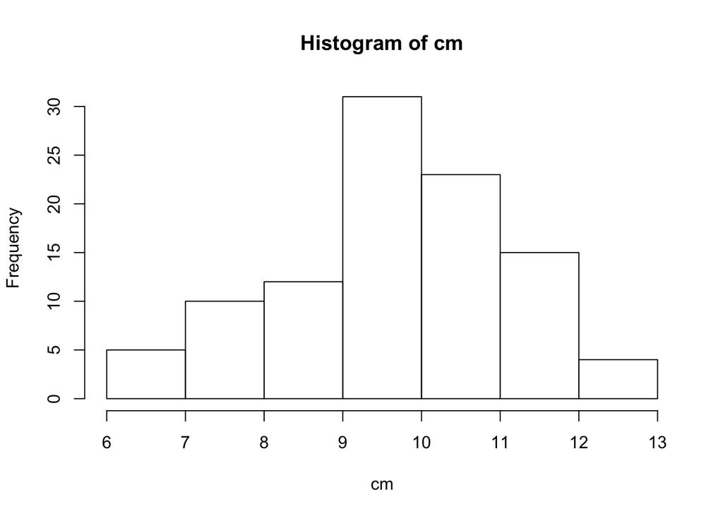

```
| You're the best!
```

```r
hist(cm)
```

*最高です。*

```
| Looks like our column means are almost normally distributed, right? That's the Central Limit
| Theorem at work, but that's a lesson for another day!

...
```

*列平均は、ほぼ、正規分布していませんか。これは、中心極限定理を表しています。いつの日か、学ぶことがあるでしょう。*

```
| All of the standard probability distributions are built into R, including exponential (rexp()),
| chi-squared (rchisq()), gamma (rgamma()), .... Well, you see the pattern.

...
```

*R には、すべての標準的な確率分布関数が付属しています。exponential (rexp()、chi-squared (rchisq()), gamma (rgamma())、などです。パターンは見えますか。*

```
| Simulation is practically a field of its own and we've only skimmed the surface of what's
| possible. I encourage you to explore these and other functions further on your own.

...
```

*シミュレーションはそれ自身実用的な分野で、今回、表面的な部分を見てみました。他の関数についても、調べてみることをお薦めします。*

```
  |=========================================================================================| 100%
| Would you like to receive credit for completing this course on Coursera.org?

1: Yes
2: No

Selection: 2
```

*Coursera.org の終了認定が欲しいですか。*

2 を選んでください。何度か説明しましたから、省略します。

```
| Excellent work!

| You've reached the end of this lesson! Returning to the main menu...

| Please choose a course, or type 0 to exit swirl.

1: R Programming
2: Take me to the swirl course repository!

Selection: 0
```

*素晴らしい。*

*課の最後までたどり着きました。メニューに戻るには、*

*コースを選択してください。swirl を終了するときは、0 を入力してください。*

*1: R によるプログラム*  
*2: ｀swirl` コースのリストへ.*

*選択：0 （SL が入力）*

```
| Leaving swirl now. Type swirl() to resume.
```

*swirl を終了します。再開するときは、swirl() と入力してください。*

```
>
```

### 2.14. Dates and Times

> この課では、日付と時刻を R でどのように扱われているかについて学びます。  
> 和訳や解説は、課を選択するところから始めます。よくわからない方は、1.2 または、1.1 の最初の部分を復習してください。

```
| Please choose a course, or type 0 to exit swirl.

1: R Programming
2: Take me to the swirl course repository!

Selection: 1

| Please choose a lesson, or type 0 to return to course menu.

 1: Basic Building Blocks      2: Workspace and Files        3: Sequences of Numbers
 4: Vectors                    5: Missing Values             6: Subsetting Vectors
 7: Matrices and Data Frames   8: Logic                      9: Functions
10: lapply and sapply         11: vapply and tapply         12: Looking at Data
13: Simulation                14: Dates and Times           15: Base Graphics


Selection: 14
```

14: Dates and Times（第14課 日付と時刻）を選択しました。

```
| R has a special way of representing dates and times, which can be helpful if you're working with
| data that show how something changes over time (i.e. time-series data) or if your data contain
| some other temporal information, like dates of birth.

...
```

*R には日付と時刻を表す特別の方法がありますが、それは、（time-series data 時間軸をともなったデータなどで）日付のある期間での変化を見たり、誕生日などの、時に関する他の情報を含んでいるデータを扱うときに有効です。*

```
| Dates are represented by the 'Date' class and times are represented by the 'POSIXct' and
| 'POSIXlt' classes. Internally, dates are stored as the number of days since 1970-01-01 and times
| are stored as either the number of seconds since 1970-01-01 (for 'POSIXct') or a list of
| seconds, minutes, hours, etc. (for 'POSIXlt').

...
```

*日付は、‘Date’ という種類（class）で、時刻を表す種類（class）は ‘POSIXct’ と ‘POSIXlt’ と二つあります。内部的には、日付は、1970-01-01 からの日数で保存され、時刻は、1970-01-01 (‘POSIXct’ clss) からの秒数で表すか、seconds, minutes, hours, などからなる (‘POSIXlt’ class) リストで、保存されています。*

```
| Let's start by using d1 <- Sys.Date() to get the current date and store it in the variable d1.
| (That's the letter 'd' and the number 1.)
```

*まず、d1 <- Sys.Date() で、現在の日付を、変数 d1 に保存しましょう。（‘d’ と 数 の 1 です。）*

```
> d1 <- Sys.Date()

| That's the answer I was looking for.
```

*そうです。それが、期待したものです。*

```
| Use the class() function to confirm d1 is a Date object.
```

*class() 関数で、d1 が Date オブジェクトであることを確認してください。*

```
> class(d1)
[1] "Date"

| Keep working like that and you'll get there!
```

*その調子で良いですよ。*

```
| We can use the unclass() function to see what d1 looks like internally. Try it out.
```

*unclass() 関数を使って、d1 が内部的には、どのようなものなのか見ることができます。試してください。*

```
> unclass(d1)
[1] 18364

| You're the best!
```

*最高です。*

```
| That's the exact number of days since 1970-01-01!

...
```

*それが、1970-01-01 からの日数です。*

```
| However, if you print d1 to the console, you'll get today's date -- YEAR-MONTH-DAY. Give it a
| try.
```

*しかし、d1 をコンソール（画面）に表示すると、今日の日付は、YEAR-MONTH-DAY（年-月-日）になります。*

```
> d1
[1] "2020-04-12"

| Great job!
```

*やりましたね。*

```
| What if we need to reference a date prior to 1970-01-01? Create a variable d2 containing
| as.Date("1969-01-01").
```

*1970-01-01 以前の日付が必要なときは、どうなると思いますか。as.Date(“1969-01-01”) を d2 という名前の変数に置いてください。*

```
> d2 <- as.Date("1969-01-01")

| You are doing so well!
```

*とてもうまくいっていますよ。*

```
| Now use unclass() again to see what d2 looks like internally.
```

*もう一度 unclass() を使って、d2 は内部的にはどうなっているか表示してください。*

```
> unclass(d2)
[1] -365

| You are really on a roll!
```

*どんどん学んでいますね。*

```
| As you may have anticipated, you get a negative number. In this case, it's -365, since
| 1969-01-01 is exactly one calendar year (i.e. 365 days) BEFORE 1970-01-01.

...
```

*想像した通りかと思いますが、負の数になりました。この場合は、1969-01-01 は、1970-01-01 から丁度一年（365日）前ですから、-365 となりました。*

```
| Now, let's take a look at how R stores times. You can access the current date and time using the
| Sys.time() function with no arguments. Do this and store the result in a variable called t1.
```

*では、R が、時間をどのように、保存しているのか見てみましょう。現在の、日付と時間を Sys.time() 関数で、引数をなにも入れないで得ることができます。結果を、t1 に保存してください。*

```
> t1 <- Sys.time()

| Excellent work!
```

*素晴らしい。*

```
| View the contents of t1.
```

*t1 を見てみましょう。*

```
> t1
[1] "2020-04-12 09:22:52 JST"

| Keep up the great work!
```

*その調子です。*

```
| And check the class() of t1.
```

*class() でオブジェクトの種類を見てください。*

```
> class(t1)
[1] "POSIXct" "POSIXt"

| That's correct!
```

*正しいです。*

```
| As mentioned earlier, POSIXct is just one of two ways that R represents time information. (You
| can ignore the second value above, POSIXt, which just functions as a common language between
| POSIXct and POSIXlt.) Use unclass() to see what t1 looks like internally -- the (large) number
| of seconds since the beginning of 1970.
```

*すでに説明したように、POSIXct は、R の二種類の時間表示のうちの一つです。（二番目は無視しましょう。POSIXt は、POSIXct と POSIXlt の両方を表すために使います。）unclass() を使って、t1 が内部的には、どのようになっているか見てみましょう。1970年からの非常に大きな秒数になります。*

```
> unclass(t1)
[1] 1586650973

| Great job!
```

*やりましたね。*

```
| By default, Sys.time() returns an object of class POSIXct, but we can coerce the result to
| POSIXlt with as.POSIXlt(Sys.time()). Give it a try and store the result in t2.
```

*初期値では、Sys.time() は、POSIXct のオブジェクトを返します。しかし、as.POSIXlt(Sys.time()) とすることで、POSIXlt に変更することができます。その結果を、t2 として保存してください。*

```
> t2 <- as.POSIXlt(Sys.time())

| Perseverance, that's the answer.
```

*頑張りましたね。それが答えです。*

```
| Check the class of t2.
```

*t2 の種類（クラス）を確認しましょう。*

```
> class(t2)
[1] "POSIXlt" "POSIXt"

| That's correct!
```

*正しいです。*

```
| Now view its contents.
```

*では、中身を見てみましょう。*

```
> t2
[1] "2020-04-12 09:24:52 JST"

| You are amazing!
```

*驚きです。*

```
| The printed format of t2 is identical to that of t1. Now unclass() t2 to see how it is different
| internally.
```

*得られた t2 の形式は、t1 のものと同じです。今度は、unclass() を使って、t2 が内部的にはどのようになっているか見てみましょう。*

```
> unclass(t2)
$sec
[1] 52.63071

$min
[1] 24

$hour
[1] 9

$mday
[1] 12

$mon
[1] 3

$year
[1] 120

$wday
[1] 0

$yday
[1] 102

$isdst
[1] 0

$zone
[1] "JST"

$gmtoff
[1] 32400

attr(,"tzone")
[1] ""    "JST" "JDT"

| You are amazing!
```

*驚きです。*

```
| t2, like all POSIXlt objects, is just a list of values that make up the date and time. Use
| str(unclass(t2)) to have a more compact view.
```

*t2 は、他の POSIXlt オブジェクト t2 と同じように、日付と、時刻に関する値のリストからなっています。str(unclass(t2)) で、もっと簡潔な形式で見てみましょう。*

```
> str(unclass(t2))
List of 11
 $ sec   : num 52.6
 $ min   : int 24
 $ hour  : int 9
 $ mday  : int 12
 $ mon   : int 3
 $ year  : int 120
 $ wday  : int 0
 $ yday  : int 102
 $ isdst : int 0
 $ zone  : chr "JST"
 $ gmtoff: int 32400
 - attr(*, "tzone")= chr [1:3] "" "JST" "JDT"

| Great job!
```

*やりましたね。*

```
| If, for example, we want just the minutes from the time stored in t2, we can access them with
| t2$min. Give it a try.
```

*たとえば、t2 に保存されている、分（minutes）を見たいときは t2$min とします。試してください。*

```
> t2$min
[1] 24

| All that hard work is paying off!
```

*努力は報われます。*

```
| Now that we have explored all three types of date and time objects, let's look at a few
| functions that extract useful information from any of these objects -- weekdays(), months(), and
| quarters().

...
```

*これで、日付と時刻を表す、三つの種類全部を見ました。これらのオブジェクトから、情報を取り出すための、weekdays(), months(), quarters() といった、いくつかの関数を見てみましょう。*

```
| The weekdays() function will return the day of week from any date or time object. Try it out on
| d1, which is the Date object that contains today's date.
```

*weekdays() 関数は、日付や、時刻のオブジェクトが、何曜日かを教えてくれます。今日の日付が保存されている d1 で試してみましょう。*

```
> weekdays(d1)
[1] "Sunday"
[日本語システム] "日曜日"

| Keep working like that and you'll get there!
```

*その調子で良いですよ。*

```
| The months() function also works on any date or time object. Try it on t1, which is the POSIXct
| object that contains the current time (well, it was the current time when you created it).
```

*months() 関数は、日付や、時刻のオブジェクトについて使えます。t1 は POSIXct 現在の時刻を保存してある（正確には、これを作成した時刻ですが）オブジェクトでした。t1 について適用してください。*

```
> months(t1)
[1] "April"
[日本語システム] "4月"

| Excellent job!
```

*素晴らしい。*

```
| The quarters() function returns the quarter of the year (Q1-Q4) from any date or time object.
| Try it on t2, which is the POSIXlt object that contains the time at which you created it.
```

*quarters() 関数は、日付または時刻のオブジェクトから、一年の四半期 (Q1-Q4) を計算して返します。POSIXlt 形式のオブジェクトで、それを保存した時刻の情報を持っている t2 について試してください。*

```
> quarters(t2)
[1] "Q2"

| Great job!
```

*やりましたね。*

```
| Often, the dates and times in a dataset will be in a format that R does not recognize. The
| strptime() function can be helpful in this situation.

...
```

*日付や、時刻は、R が認識できない形式になっていることもあります。そのときは、strptime() 関数が助けとなります。*

```
| strptime() converts character vectors to POSIXlt. In that sense, it is similar to as.POSIXlt(),
| except that the input doesn't have to be in a particular format (YYYY-MM-DD).

...
```

*strptime() 関数は、文字列ベクトルと、POSIXlt 形式に変換します。その意味で、as.POSIXlt() と似た働きをしますが、YYYY-MM-DD といった、特定の形式である必要はありません。*

```
| To see how it works, store the following character string in a variable called t3: "October 17,
| 1986 08:24" (with the quotes).
```

*どのように働くかみるために、二重引用符を付けて文字列ベクトルとして、“October 17, 1986 08:24” を t3 という名前の変数として保存してください。*

```
> t3 <- "October 17, 1986 08:24"

| You are really on a roll!
```

*どんどん学んでいますね。*

```
| Now, use strptime(t3, "%B %d, %Y %H:%M") to help R convert our date/time object to a format that
| it understands. Assign the result to a new variable called t4. (You should pull up the
| documentation for strptime() if you'd like to know more about how it works.)
```

*strptime(t3, “%B %d, %Y %H:%M”) として、R が date/time オブジェクトとして認識して変換できるように、してください。結果を、 t4 という名前で保存してください。（strptime() についてもっと詳しく知りたいときは、Help を読んでください。）*

```
> t4 <- strptime(t3, "%B %d, %Y %H:%M")

| Excellent work!
```

*素晴らしい。*

```
| Print the contents of t4.
```

*t4 の中身を表示してください。*

```
> t4
[1] "1986-10-17 08:24:00 UTC"
[日本語システム] NA

| That's the answer I was looking for.
```

*そうです。それが、期待したものです。*

**注：** strptime() はシステムが日本語か英語で挙動が異なります。swirl を RStudio.cloud（英語システム）で使っている場合は、同じ問題でかまいませんが、日本語システムの時は、あとで、t4 の値を求めると、NA となります。それでも、気にせず、先に進むことで問題ありません。“October 17, 1986 08:24” の部分を、t4 <- “1986年 10月 17日, 08:24” として、strptime(t4,“%Y年 %m月 %d日, %H: %M”) とすれば同じことが可能です。strptime(“1986年 10月 17日, 08:24”,“%Y年 %m月 %d日, %H: %M”) 等として確かめてください。なお、UTC は、協定世界時（Coordinated Universal Time）で、日本で使っていれば、JST 日本標準時になります。

```
| That's the format we've come to expect. Now, let's check its class().
```

*それが、期待した形式です。class() で、オブジェクトの種類を確認してください。*

```
> class(t4)
[1] "POSIXlt" "POSIXt"

| You are doing so well!
```

*とてもうまくいっていますよ。*

```
| Finally, there are a number of operations that you can perform on dates and times, including
| arithmetic operations (+ and -) and comparisons (<, ==, etc.)

...
```

*最後に、日付や時刻に対する数の演算 (+ と -) や、比較の (<, ==, など) について学びます。*

```
| The variable t1 contains the time at which you created it (recall you used Sys.time()). Confirm
| that some time has passed since you created t1 by using the 'greater than' operator to compare
| it to the current time: Sys.time() > t1
```

*変数 t1 は、Sys.time() を使ったときの時刻を保存してあります。それが、現在の時刻よりも小さいことを、Sys.time() > t1 で、確認しましょう。*

```
> Sys.time() > t1
[1] TRUE

| Great job!
```

*やりましたね。*

```
| So we know that some time has passed, but how much? Try subtracting t1 from the current time
| using Sys.time() - t1. Don't forget the parentheses at the end of Sys.time(), since it is a
| function.
```

*時間が経過したことがわかります。次に、Sys.time() - t1 で、現在の時刻から、t1 を引いてください。Sys.time() は関数ですから、最後に括弧を付けるのを忘れないでください。*

```
> Sys.time() - t1
Time difference of 9.99543 mins

| You are quite good my friend!
```

*いい具合ですね。*

```
| The same line of thinking applies to addition and the other comparison operators. If you want
| more control over the units when finding the above difference in times, you can use difftime(),
| which allows you to specify a 'units' parameter.

...
```

*同様にして、加法や、他の比較の作用素を使うこともできます。また、difftime() を使って、時間の差も計算することができ、‘units’（単位）を指定することもできます。*

```
| Use difftime(Sys.time(), t1, units = 'days') to find the amount of time in DAYS that has passed
| since you created t1.
```

*difftime(Sys.time(), t1, units = ‘days’) を使って、t1 を保存したときから、何日たったか調べてください。*

```
> difftime(Sys.time(), t1, units = 'days')
Time difference of 0.007301148 days

| You are amazing!
```

*驚きです。*

```
  |=======================================================================================  |  97%
| In this lesson, you learned how to work with dates and times in R. While it is important to
| understand the basics, if you find yourself working with dates and times often, you may want to
| check out the lubridate package by Hadley Wickham.

...
```

*この課では、日付や、時刻を R がどのように扱うかについて学びました。基本を学ぶことは、大切ですが、もし、日付や時刻を、頻繁に使うのであれば、Hadley Wickham による、lubridate package についても、調べてみると良いでしょう。*

```
  |=========================================================================================| 100%
| Would you like to receive credit for completing this course on Coursera.org?

1: No
2: Yes

Selection: 1
```

*Coursera.org の終了認定が欲しいですか。*

1 を選んでください。何度か説明しましたから、省略します。

```
| Excellent work!

| You've reached the end of this lesson! Returning to the main menu...

| Please choose a course, or type 0 to exit swirl.

1: R Programming
2: Take me to the swirl course repository!

Selection: 0
```

*素晴らしい。*

*課の最後までたどり着きました。メニューに戻るには、*

*コースを選択してください。swirl を終了するときは、0 を入力してください。*

*1: R によるプログラム*  
*2: ｀swirl` コースのリストへ.*

*選択：0 （SL が入力）*

```
| Leaving swirl now. Type swirl() to resume.
```

*swirl を終了します。再開するときは、swirl() と入力してください。*

```
>
```